# Fuelling the Forecast

A Time Series Analysis of US Gasoline Supply:1991-2017

Aditi Sharma

15.03.2026

## Framing & Data

The dataset is **US gasoline supply** (`us_gasoline`), converted from 1,355 weekly observations which are aggregated to 312 monthly observations, spanning February 1991 to January 2017. The unit is millions of barrels per day, the frequency is 12 observations per year, and the research question centres on understanding and forecasting American gasoline consumption patterns across 26 years of economic history.

Gasoline supply is not just numbers — it is a mirror of American economic and social history: recessions, post-9/11 shifts, the 2008 financial crisis, the shale revolution, and changing consumer behaviour all leave fingerprints in this data.

## 1 Exploratory Time-Series Insights

### 1.1 Loading and Inspecting the Series

```r
#Load the dataset
data(us_gasoline)

#Check the dataset
head(us_gasoline)
```

```
## # A tsibble: 6 x 2 [1W]
##       Week Barrels
##     <week>   <dbl>
## 1 1991 W06    6.62
## 2 1991 W07    6.43
## 3 1991 W08    6.58
## 4 1991 W09    7.22
## 5 1991 W10    6.88
## 6 1991 W11    6.95
```

```r
str(us_gasoline)
```

```
## tbl_ts [1,355 × 2] (S3: tbl_ts/tbl_df/tbl/data.frame)
##  $ Week   : week [1:1355] 1991 W06, 1991 W07, 1991 W08, 1991 W09, 1991 W10, 1991 W...
##  $ Barrels: num [1:1355] 6.62 6.43 6.58 7.22 6.88 ...
##  - attr(*, "key")= tibble [1 × 1] (S3: tbl_df/tbl/data.frame)
##   ..$ .rows: list<int> [1:1]
##   .. ..$ : int [1:1355] 1 2 3 4 5 6 7 8 9 10 ...
##   .. ..@ ptype: int(0)
##  - attr(*, "index")= chr "Week"
##   ..- attr(*, "ordered")= logi TRUE
##  - attr(*, "index2")= chr "Week"
##  - attr(*, "interval")= interval [1:1] 1W
##   ..@ .regular: logi TRUE
```

```r
show(us_gasoline)
```

```
## # A tsibble: 1,355 x 2 [1W]
##        Week Barrels
##      <week>   <dbl>
##  1 1991 W06    6.62
##  2 1991 W07    6.43
##  3 1991 W08    6.58
##  4 1991 W09    7.22
##  5 1991 W10    6.88
##  6 1991 W11    6.95
##  7 1991 W12    7.33
##  8 1991 W13    6.78
##  9 1991 W14    7.50
## 10 1991 W15    6.92
## # ℹ 1,345 more rows
```

```r
glimpse(us_gasoline)
```

```
## Rows: 1,355
## Columns: 2
## $ Week    <week> 1991 W06, 1991 W07, 1991 W08, 1991 W09, 1991 W10, 1991 W11, 1…
## $ Barrels <dbl> 6.621, 6.433, 6.582, 7.224, 6.875, 6.947, 7.328, 6.777, 7.503,…
```

```r
#Save it as a CSV file
write.csv(us_gasoline, "us_gasoline.csv", row.names = FALSE)


# Filter and plot to confirm it looks good
gasoline_monthly <- us_gasoline %>%
  index_by(Month = yearmonth(Week)) %>%
  summarise(Barrels = mean(Barrels)) %>%
  select(Month, Barrels)

gasoline_monthly
```

```
## # A tsibble: 312 x 2 [1M]
##       Month Barrels
##       <mth>   <dbl>
##  1 1991 Feb    6.72
##  2 1991 Mar    6.98
##  3 1991 Apr    7.08
##  4 1991 May    7.19
##  5 1991 Jun    7.53
##  6 1991 Jul    7.55
##  7 1991 Aug    7.48
##  8 1991 Sep    7.16
##  9 1991 Oct    7.37
## 10 1991 Nov    7.04
## # ℹ 302 more rows
```

```r
# Check the interval/frequency of the series
interval(gasoline_monthly)
```

```
## <interval[1]>
## [1] 1M
```

```r
frequency(gasoline_monthly)
```

```
## [1] 12
```

```r
#Also confirms it's a monthly tsibble
#Convert to ts object
gasoline_ts <- as.ts(gasoline_monthly)
gasoline_ts
```

```
##           Jan      Feb      Mar      Apr      May      Jun      Jul      Aug
## 1991          6.715000 6.981750 7.079200 7.191750 7.533500 7.554800 7.479250
## 1992 6.930000 6.846750 7.087000 7.370750 7.338000 7.382600 7.615000 7.600200
## 1993 6.828000 7.096750 7.137000 7.305000 7.396600 7.701000 7.735750 7.763200
## 1994 6.935800 7.284500 7.403500 7.460250 7.560600 7.814750 7.668000 7.894400
## 1995 7.234200 7.348500 7.843500 7.754500 8.006200 8.188250 8.192000 8.017500
## 1996 7.465200 7.638000 7.775500 7.637600 7.923750 8.105500 8.096200 8.068250
## 1997 7.309500 7.583250 7.775600 7.962750 8.065000 8.175800 8.522750 8.352250
## 1998 7.765500 7.885250 8.117600 8.160500 8.142250 8.394800 8.526250 8.581200
## 1999 7.811750 8.138000 8.277400 8.173000 8.337800 8.867500 8.619250 8.633200
## 2000 7.879200 8.144750 8.285750 8.532500 8.653400 8.598250 8.619400 8.800750
## 2001 7.974200 8.139500 8.472750 8.504200 8.567750 8.694500 8.971800 8.815250
## 2002 8.203750 8.514000 8.499250 8.721800 8.800250 8.924750 9.087000 9.129250
## 2003 8.581000 8.400000 8.604800 8.642250 8.925250 8.953600 9.201500 9.427750
## 2004 8.473500 8.780000 8.962000 9.123000 9.190000 9.252500 9.178250 9.427400
```

[output cut: 41 more lines]

```r
# Confirm with ts object
length(gasoline_ts)
```

```
## [1] 312
```

```r
start(gasoline_ts)
```

```
## [1] 1991    2
```

```r
end(gasoline_ts)
```

```
## [1] 2017    1
```

```r
frequency(gasoline_ts)
```

```
## [1] 12
```

```r
# No.of observations for our specific filtered series
nrow(gasoline_monthly)
```

```
## [1] 312
```

```r
# Clean summary of all key facts in one place
cat("=== Series Summary: Months, Barrels ===\n")
```

```
## === Series Summary: Months, Barrels ===
```

```r
cat("Frequency:          ", frequency(gasoline_ts), "observations per year\n")
```

```
## Frequency:           12 observations per year
```

```r
cat("Start date:         ", start(gasoline_ts)[1],
    "month", start(gasoline_ts)[2], "\n")
```

```
## Start date:          1991 month 2
```

```r
cat("End date:           ", end(gasoline_ts)[1],
    "month", end(gasoline_ts)[2], "\n")
```

```
## End date:            2017 month 1
```

```r
cat("Number of obs:      ", length(gasoline_ts), "\n")
```

```
## Number of obs:       312
```

```r
cat("Years covered:      ",
    round(length(gasoline_ts)/frequency(gasoline_ts), 1), "\n")
```

```
## Years covered:       26
```

*“What are we looking at, and why does it matter?”*

The US Energy Information Administration has tracked weekly gasoline supplied to the American market since the early 1990s. This series — aggregated to monthly averages across 312 months, captures something fundamental: how much gasoline Americans actually consumed, not just produced or imported. It’s a proxy for economic activity, commuting behavior, and industrial output all at once.

What our data setup shows:

1,355 weekly observations collapsed into 312 monthly averages (Feb 1991 → Jan 2017) Unit: millions of barrels per day supplied The aggregation from weekly → monthly (312 monthly observations) smooths noise while preserving structural patterns.

### 1.2 Time Plot

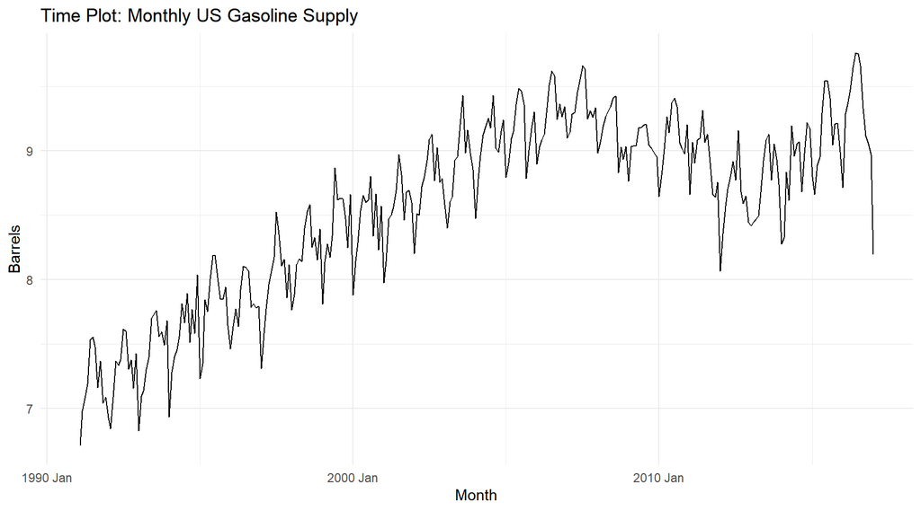

```r
# Time Plot

gasoline_monthly %>%
  autoplot(Barrels) +
  labs(
    title = "Time Plot: Monthly US Gasoline Supply",
    x = "Month",
    y = "Barrels"
  ) +
  theme_minimal()
```

**Interpretation:**

Phase 1: The Growth Era (1991-2007)

The series shows a clear, sustained upward trend across nearly 16 years. This mirrors America’s economic expansion, the 1990s dot-com boom drove suburban sprawl, SUV culture took hold, and low gas prices encouraged high consumption. Supply rose steadily from ~6.6 to nearly 9.6 million barrels/day, reflecting both population growth and rising vehicle miles travelled.

Phase 2: The Structural Break (2007-2009)

Around 2007-2008, the trend sharply reverses, this is the fingerprint of the Global Financial Crisis. Unemployment surged, commuting dropped, and discretionary driving collapsed. This is the most important structural break in the series and cannot be ignored in modelling.

Phase 3: The Lost Decade (2009-2012)

Recovery is weak and volatile as gasoline did not immediately return to it’s pre-crisis trend. Fuel-efficient cars entered the fleet, and remote work began emerging.

Phase 4: Modest Rebound (2012-2017)

A gentle recovery driven by the shale oil boom crashing fuel prices, encouraging driving again, but with noticeably higher month-to-month volatility than pre-crisis.

Modelling Implication(s):

The presence of a structural break around 2008 means a single linear trend would misrepresent the data. The post-2008 regime behaves differently from pre-2008, suggesting the need for intervention variables or piecewise modelling. Additionally, the visible seasonal oscillations throughout confirm a seasonal component must be explicitly modelled.

### 1.3 Seasonal Subseries Plot

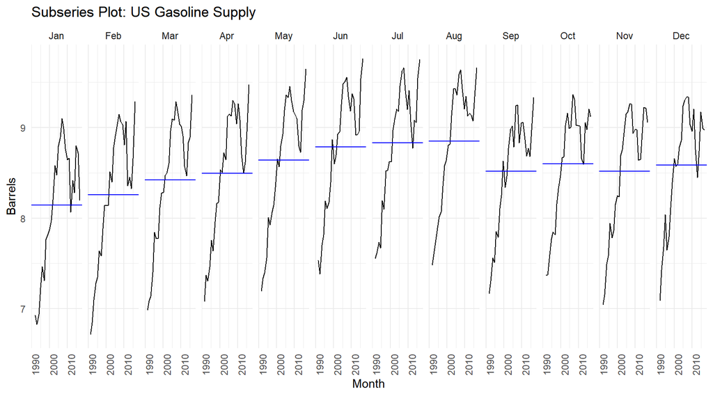

```r
## Seasonal (subseries) Plot

gasoline_monthly %>%
  gg_subseries(Barrels) +
  labs(
    title = "Subseries Plot: US Gasoline Supply",
    x = "Month",
    y = "Barrels"
  ) +
  theme(legend.position = "none")
```

The series has frequency = 12, meaning 12 observations per year, one per month. This matters because:

When we difference later, lag = 12 is our seasonal lag. If we used lag = 4 (quarterly) or lag = 52 (weekly), we’d be removing the wrong cycle entirely. The monthly frequency is what tells us “one full season = 12 steps back.”

**Trend : What Each Panel Tells**

This confirms the trend is not just a global feature, it lives inside every month. Growth was broad-based across all seasons, not driven by one particular time of year. However, looking at the within-panel trajectories, you can also see the 2008 dip visible in every single month, the crisis hit all seasons equally hard, reinforcing that it was a structural break, not a seasonal anomaly.

**Seasonality : The Calendar Pattern**

The seasonality is consistent and repetitive across all 26 years, which is exactly what you need to justify using seasonal differencing and seasonal model components.

**Variance : Do the Swings Grow?**

This is a subtle but important observation. Looking at the spread of values within each month’s panel, the variance appears broadly stable, the vertical range of each panel does not dramatically widen as you move from the 1990s to the 2010s. The oscillations don’t balloon as the level rises.

It suggests additive seasonality. You don’t need a log transformation to stabilise variance (though log is still defensible for normalising the level). An additive decomposition model is therefore appropriate.

**Narrative Interpretation**

The subseries plot disaggregates the series by calendar month, revealing that American gasoline consumption follows a deeply rhythmic annual calendar that held remarkably consistent across all 26 years of observation. Supply reliably peaks across the summer months of June, July, and August, driven by the cultural institution of the American summer road trip, school holidays, and heightened leisure travel. January and February sit at the opposite extreme, reflecting reduced mobility in cold weather and the post-Christmas economic slowdown.

Critically, this seasonal rhythm did not break even during the 2008 financial crisis, the pattern persisted, but at a lower level, visible as a downward shift in every month’s within-panel trajectory from around 2008 onward. The calendar kept its shape; only the volume changed. This tells us the crisis altered the level of consumption permanently, but not the behavioural seasonality of when Americans drive.

The relatively stable within-month variance across decades further confirms that the seasonal swings are additive in nature, summer demand exceeds winter demand by a roughly constant margin, regardless of the overall level of supply. This guides us toward additive decomposition and supports the use of seasonal differencing at lag 12 in subsequent modelling.

### 1.4 Log Transformation

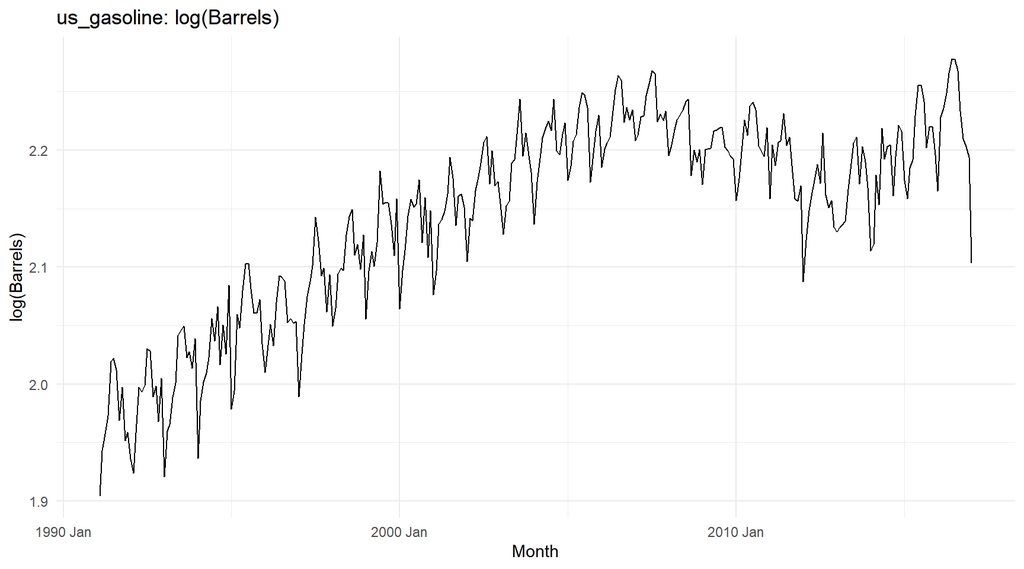

```r
## Log Transformation

gasoline_monthly <- gasoline_monthly %>%
  mutate(log_Barrels = log(Barrels))

## Plot log-transformated series

autoplot(gasoline_monthly, log_Barrels) +
  labs(
    title = "us_gasoline: log(Barrels)",
    x = "Month",
    y = "log(Barrels)"
  )
```

**What Motivated the Log Transformation?**

Looking back at the original time plot, the motivation was to test for proportional variance, specifically, whether the seasonal swings were growing in size as the overall level of supply increased. If summer peaks get proportionally bigger as the series rises, the variance is multiplicative and log transformation is the fix.

A second motivation is purely about how many times series models assume approximately constant variance and how many time series models perform better on series where percentage changes are more meaningful than absolute changes. Log transformation converts the series into one where differences represent growth rates, which is economically intuitive for a supply series.

**Did It Work? Direct Comparison**

The honest answer is that the log transformation did not dramatically alter the series’ appearance. The overall shape is essentially identical, the same upward trend, the same 2008 structural break, the same seasonal oscillations, all preserved. The y-axis simply rescales from raw barrels (~6.6 to ~9.7) into log units (~1.9 to ~2.27), but the visual story is unchanged.

The seasonal swing size looks just as stable in the log plot as in the original, which actually confirms what the subseries plot already suggested — the series has additive, not multiplicative seasonality. Variance stabilisation was never urgently needed here. The transformation is defensible but not transformative, a modest refinement rather than a correction of a serious problem.

**Narrative Interpretation**

A natural question when examining any economic supply series is whether its fluctuations grow proportionally as the underlying level rises. For gasoline supply, this would mean the gap between a summer peak and a winter trough in 2005 should be larger in absolute barrels than the same gap in 1993, simply because the overall supply level is higher. This would make economic sense: the shale revolution of the mid-2000s dramatically expanded America’s domestic energy production capacity, which could plausibly have amplified seasonal supply responses.

However, the log-transformed plot tells a more restrained story. The shape is almost indistinguishable from the original, the growth phase of 1991-2007, the sharp 2008 contraction, and the volatile post-recession plateau all appear in identical form. The seasonal oscillations did not visibly shrink under the log compression, confirming they were already roughly constant in absolute size across all 26 years.

This is actually a meaningful real-world finding: American gasoline demand seasonality is structurally stable in absolute volume terms. Summer driving season adds roughly the same number of barrels above the winter baseline whether the year is 1995 or 2012, the calendar behaviour of American drivers persists regardless of economic conditions or energy market shifts. The log series will be retained for modelling robustness, but additive decomposition remains the appropriate framework.

### 1.5 First Differencing

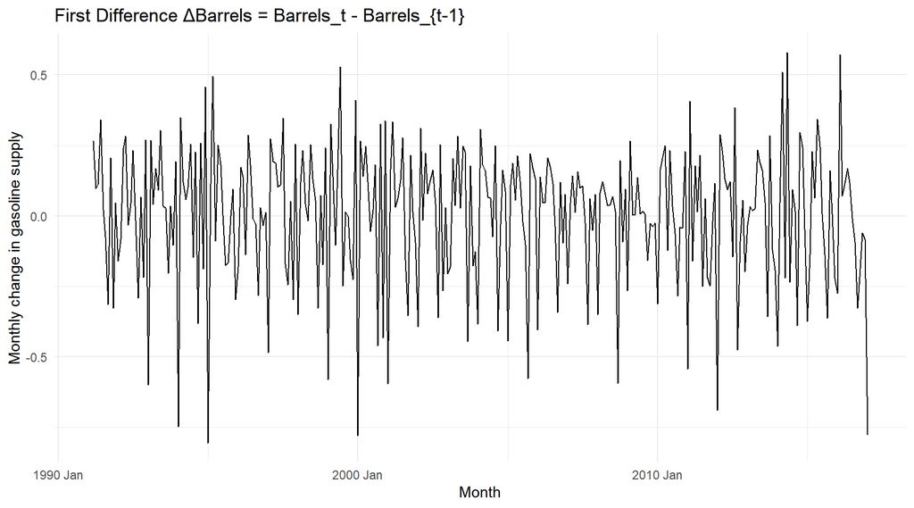

```r
## First Differencing

gasoline_monthly <- gasoline_monthly %>%
  mutate(diff1 = difference(Barrels))

## Plot first differences

gasoline_monthly %>%
  filter(!is.na(diff1)) %>%
  autoplot(diff1) +
  labs(
    title = "First Difference ΔBarrels = Barrels_t - Barrels_{t-1}",
    x = "Month",
    y = "Monthly change in gasoline supply"
  ) +
  theme_minimal()
```

**What Does First Differencing Remove?**

First differencing removes the trend from the series. By subtracting each month’s value from the previous month’s value, I am left with only the month-to-month changes in gasoline supply rather than the levels themselves. The long upward climb visible in the original plot, all 26 years of growth, gets stripped away, and what remains tells me how much supply changed each month rather than where it stood.

**Does the Differenced Series Look Stationary?**

Looking at the plot, the series now oscillates around zero across the entire time span, which is a strong visual sign that the trend has been successfully removed. There is no longer any upward or downward drift, the mean appears roughly constant throughout.

However, it is not fully stationary yet. I can still see a repeating oscillation pattern in the differenced series, the values regularly swing up and down in a rhythm that looks seasonal. This tells me that while first differencing handled the trend, the annual seasonal cycle is still present in the residuals. The series needs seasonal differencing on top of this to become truly stationary.

Also notice that the variance looks broadly stable across the full period, though there is a slightly denser cluster of spikes around the 2000s period and a notable sharp drop visible around 2008-2009, the financial crisis leaving its mark even in the differenced series.

**Narrative Interpretation**

The differenced plot is seen as a series that bounces around zero throughout the entire 1991-2017 period, confirming that first differencing successfully removed the upward trend. But the rhythm is unmistakeable: the series keeps swinging up and down in a regular pattern, the fingerprint of the summer driving season still echoing through even after trend removal. June reliably pulls supply upward relative to May. September pulls it back down as road trip season ends. These are not random fluctuations, they are the predictable behavioural patterns of American drivers encoded in the data.

### 1.6 Seasonal Differencing

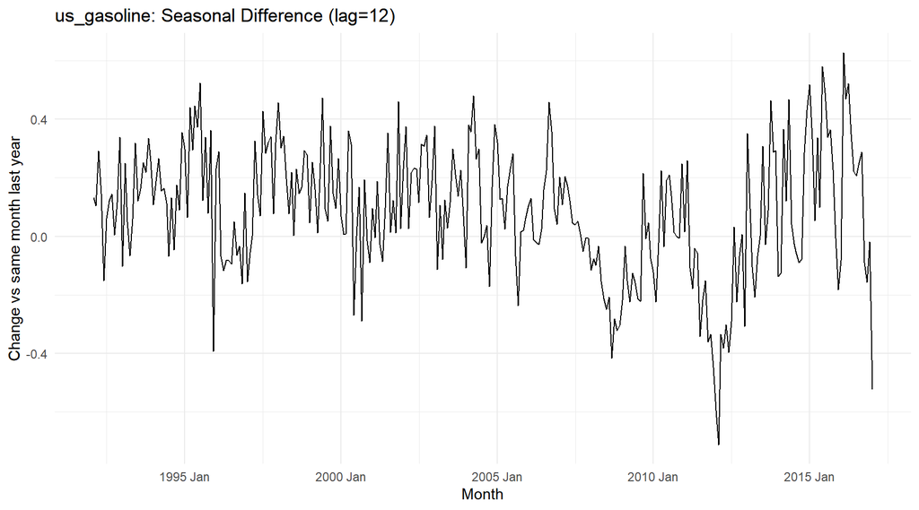

```r
## Seasonal Differencing

gasoline_monthly <- gasoline_monthly %>%
  mutate(diff12 = difference(Barrels, lag = 12))


## Plot seasonal difference

gasoline_monthly %>%
  filter(!is.na(diff12)) %>%
  autoplot(diff12) +
  labs(
    title = "us_gasoline: Seasonal Difference (lag=12)",
    x = "Month",
    y = "Change vs same month last year"
  )
```

**What Lag and Why?**

The lag chosen is lag = 12 because the series has monthly frequency, meaning one full seasonal cycle spans exactly 12 observations. By subtracting each month’s value from the same month in the previous year, the comparison becomes like-for-like: this January against last January, this August against last August. Using any other lag would compare incompatible seasons and produce meaningless differences.

**What Does Seasonal Differencing Remove That First Differencing Doesn’t?**

First differencing removed the trend but left the seasonal cycle intact, the rhythmic up-down pattern remained visible in that plot. Seasonal differencing at lag 12 removes the annual seasonal pattern instead. By comparing each month to its equivalent a year prior, the regular summer peaks and winter troughs cancel out, leaving behind only the year-over-year change in supply stripped of calendar effects.

**Narrative Interpretation**

The seasonal difference plot reframes the question entirely, instead of asking how much gasoline supply changed from last month, it now asks how much it changed compared to the same month last year. This year-over-year lens is actually how energy analysts and economists naturally discuss consumption trends, making this transformation particularly meaningful.

The rebound after 2012, when the series climbs back toward and above zero, captures the shale-driven price drop making driving affordable again. This plot is arguably the clearest single visual of the 2008 crisis impact in the entire analysis.”

### 1.7 Multi-Panel Comparison

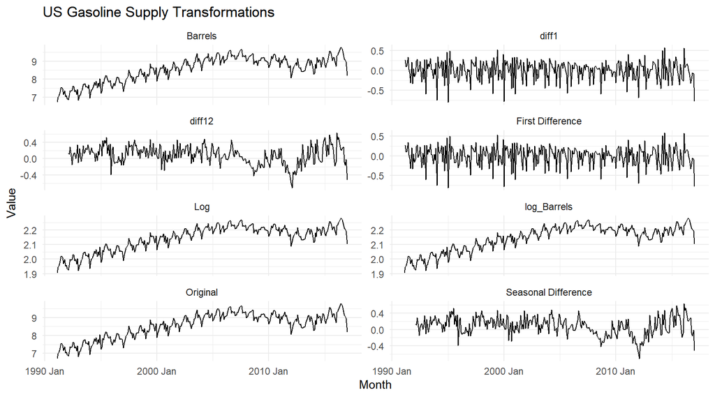

```r
## Multi-panel comparison plots

gasoline_monthly %>%
  mutate(
    `Original` = Barrels,
    `Log` = log_Barrels,
    `First Difference` = difference(Barrels),
    `Seasonal Difference` = difference(Barrels, lag = 12)
  ) %>%
  pivot_longer(-Month, names_to = "Series", values_to = "Value") %>%
  ggplot(aes(x = Month, y = Value)) +
  geom_line() +
  facet_wrap(~Series, scales = "free_y", ncol = 2) +
  labs(
    title = "US Gasoline Supply Transformations",
    x = "Month",
    y = "Value"
  ) +
  theme_minimal()
```

The Original and Log panels tell the same story, an upward trending, non-stationary series with stable seasonal oscillations. The log rescales the y-axis but changes nothing structural, confirming additive variance throughout.

The First Difference panel successfully eliminates the trend, the series now fluctuates around zero, but a seasonal rhythm is still visibly embedded in the oscillations, meaning stationarity is incomplete.

The Seasonal Difference panel removes the annual cycle but retains a prolonged negative drift around 2008-2012, meaning the trend has not been addressed. Neither transformation alone is sufficient.

The critical takeaway from viewing all panels together is that both differencing operations are needed simultaneously, d=1 to remove the trend and D=1 at lag 12 to remove the seasonal pattern.

What the panel comparison makes strikingly clear is that no single transformation completes the job alone. The financial crisis of 2008 is present in every panel, stubborn, persistent, and visible regardless of which mathematical lens is applied. This is not noise. It is history, and any forecasting model built on this series must account for it.

### 1.8 Descriptive Statistics

```r
# Check the time interval of the tsibble
interval(gasoline_monthly)
```

```
## <interval[1]>
## [1] 1M
```

```r
# View start and end dates of the dataset
range(gasoline_monthly$Month)
```

```
## <yearmonth[2]>
## [1] "1991 Feb" "2017 Jan"
```

```r
# Convert to tibble and compute descriptive statistics by month
gasoline_monthly |>
  as_tibble() |>
  mutate(Month_name = month(Month, label = TRUE)) |>
  group_by(Month_name) |>
  summarise(
    Mean = mean(Barrels),
    Min = min(Barrels),
    Max = max(Barrels),
    SD = sd(Barrels)
  ) |>
  arrange(Month_name)
```

```
## # A tibble: 12 × 5
##    Month_name  Mean   Min   Max    SD
##    <ord>      <dbl> <dbl> <dbl> <dbl>
##  1 Jan         8.14  6.83  9.10 0.683
##  2 Feb         8.26  6.72  9.29 0.752
##  3 Mar         8.42  6.98  9.36 0.711
##  4 Apr         8.50  7.08  9.47 0.708
##  5 May         8.64  7.19  9.64 0.724
##  6 Jun         8.79  7.38  9.76 0.681
##  7 Jul         8.83  7.55  9.75 0.671
##  8 Aug         8.85  7.48  9.66 0.673
##  9 Sep         8.51  7.16  9.33 0.633
## 10 Oct         8.60  7.37  9.36 0.619
## 11 Nov         8.51  7.04  9.26 0.688
## 12 Dec         8.58  7.09  9.34 0.635
```

**Does the Series Show Trend, Seasonality, or Irregular Behaviour?**

The statistics confirm all three features simultaneously. The monthly means rise steadily from January (8.14) through August (8.85) before falling back toward December (8.58), this is the seasonal pattern in numerical form, with 0.7 million barrels per day between January and August.

The standard deviations are remarkably consistent across all months, ranging narrowly between 0.619 (October) and 0.752 (February). This uniformity confirms what the visual plots already suggested, variance is stable and additive across all seasons. No single month behaves more erratically than another.

The wide gap between minimum and maximum values in every month — often exceeding 2 barrels, reflects the long upward trend across 26 years rather than irregular behaviour. January’s minimum of 6.83 came from the early 1990s; its maximum of 9.10 from the mid-2000s peak. The series is clearly non-stationary in level but structured and predictable in its seasonal shape.

### 1.9 Lag Plots

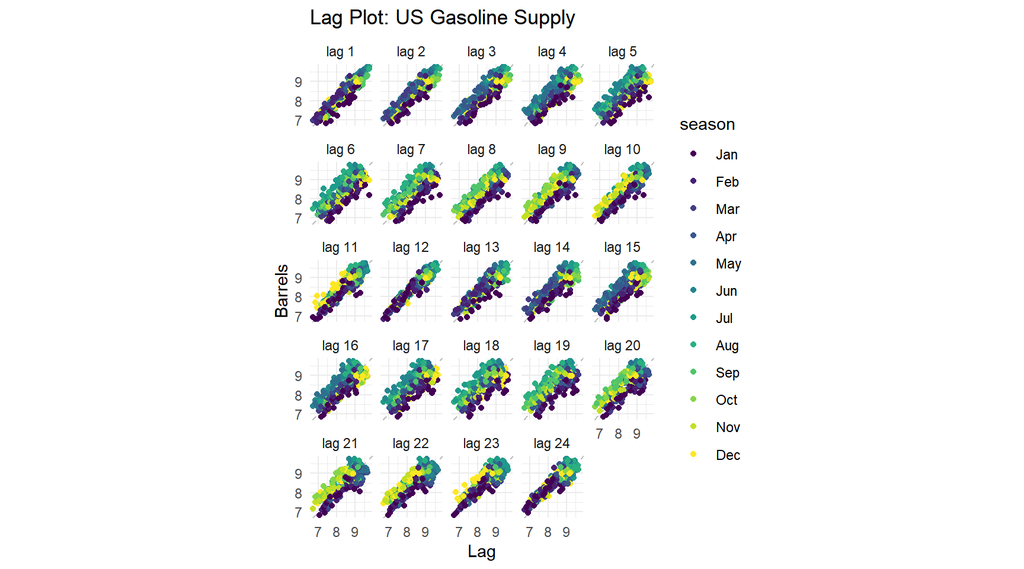

```r
# Lag plot to inspect autocorrelation structure
# 24 lags = 2 full seasonal cycles (2 x 12 months)

gasoline_monthly |>
  gg_lag(Barrels, lags = 1:24, geom = "point") +
  labs(
    title = "Lag Plot: US Gasoline Supply",
    x = "Lag",
    y = "Barrels"
  )
```

**Which Lags Show the Strongest Patterns?**

The colour coding by season reveals something additional and important. At lag 12 and lag 24, the seasonal colours cluster together distinctly, summer months (green tones) group with summer months, winter months (dark tones) group with winter months. The diagonal relationship at these lags is noticeably tighter than at intermediate lags like 6 or 18, where colours mix more freely across the diagonal. This tightening at multiples of 12 is the direct visual confirmation of annual seasonality, each month is most strongly correlated with the same month one and two years prior.

**Narrative Interpretation**

The lag plot delivers perhaps the most intuitive confirmation of everything the previous plots suggested. The tight diagonal clusters across all 24 lags tell a simple story: in the American gasoline market, the past is an extremely reliable guide to the present. A high-supply month reliably follows a high-supply month, and a low-supply month follows a low-supply month, the momentum of the series is strong and persistent across two full seasonal cycles.

The seasonal colour clustering at lags 12 and 24 captures something behaviourally real, August driving season this year looks almost identical to August driving season last year and the year before. American summer mobility is not random. It is a structural feature of how the country moves, embedded so deeply into the data that it remains visible even across a 26-year span that includes a financial crisis, two recessions, and an energy revolution.

### 1.10 White Noise Benchmark

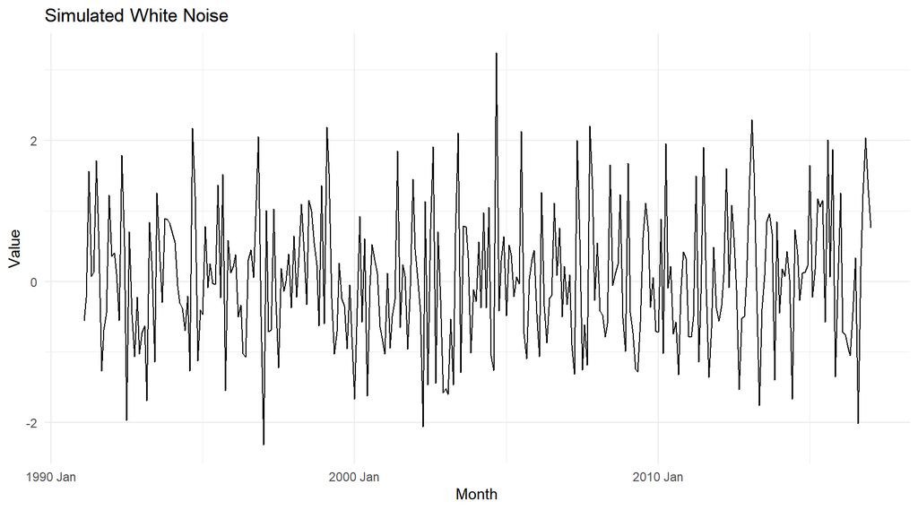

```r
# Simulate white noise with same length as gasoline data
set.seed(123)

wn_vals <- rnorm(nrow(gasoline_monthly), mean = 0, sd = 1)

white_noise <- tsibble(
  Month = min(gasoline_monthly$Month) + 0:(nrow(gasoline_monthly)-1),
  wn = wn_vals,
  index = Month
)

# White noise should show no trend or structure
autoplot(white_noise, wn) +
  labs(
    title = "Simulated White Noise",
    x = "Month",
    y = "Value"
  )
```

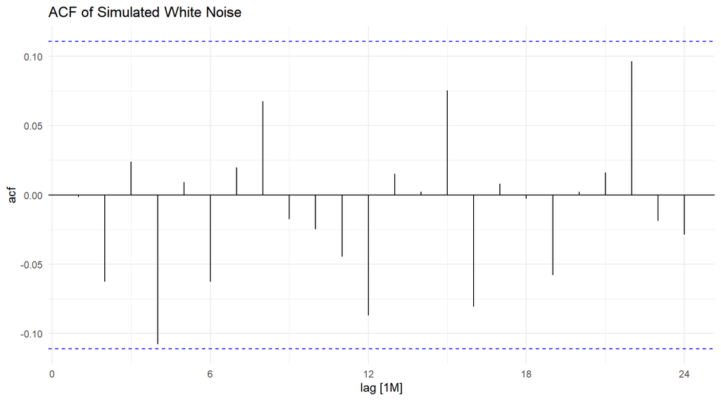

```r
# ACF should show no significant correlations
white_noise %>%
  ACF(wn, lag_max = 24) %>%
  autoplot() +
  labs(title = "ACF of Simulated White Noise")
```

```r
# Ljung-Box test checks if data behaves like white noise
white_noise %>%
  features(wn, ljung_box, lag = 24, dof = 0)
```

```
## # A tibble: 1 × 2
##   lb_stat lb_pvalue
##     <dbl>     <dbl>
## 1    20.3     0.679
```

**ACF Shape of Simulated White Noise**

The ACF of the simulated white noise shows all spikes scattered randomly and closely around zero, with virtually all bars falling well within the blue dashed confidence bands. There is no slow decay, no seasonal bumps, no pattern whatsoever, just random variation around zero across all 24 lags.

**Ljung-Box Test**

The null hypothesis is that the series is white noise, that all autocorrelations up to lag 24 are jointly equal to zero, meaning no exploitable structure exists in the data.

The p-value returned is 0.679, far above any conventional significance threshold of 0.05. The null hypothesis cannot be rejected, formally confirming that the simulated series contains no significant autocorrelation structure.

**Can This Series Be Treated as White Noise?**

Yes, the simulated series passes every criterion. The time plot fluctuates randomly around zero with stable variance, the ACF shows no significant spikes, and the Ljung-Box test formally confirms the absence of any structure. This serves as the benchmark against which the gasoline series will be compared in the ACF/PACF section.

**Narrative Interpretation**

Before examining the memory structure of the gasoline series, a baseline is established using simulated white noise of identical length. A truly random series has no past, no pattern, and no seasonal rhythm, it simply fluctuates around zero with no information carried forward from one month to the next. The ACF confirms this visually, and the Ljung-Box test confirms it statistically. This benchmark makes the contrast with the gasoline series, when it comes, all the more striking.

### 1.11 ACF & Ljung-Box Test

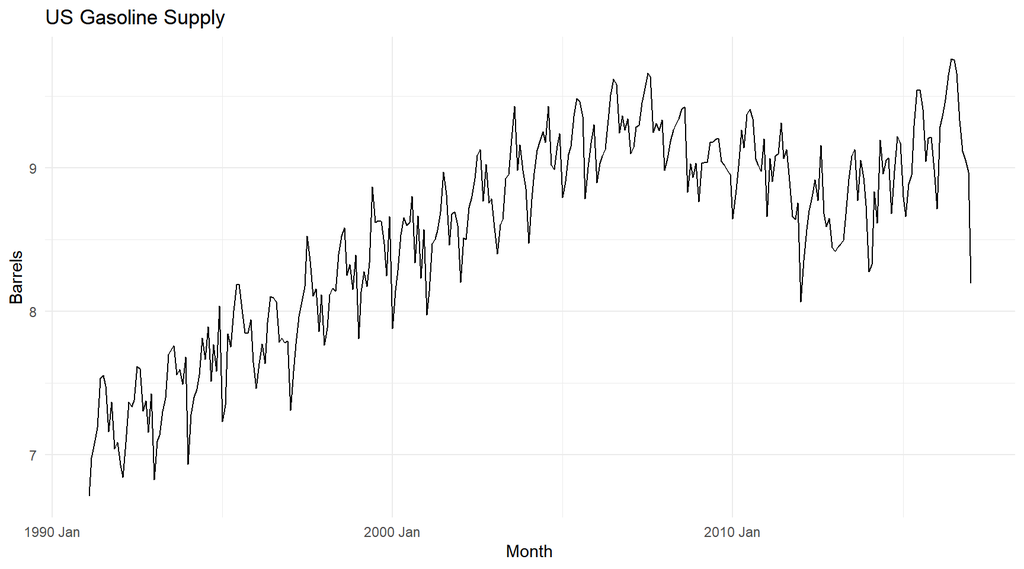

```r
# Plot the gasoline supply time series
autoplot(gasoline_monthly, Barrels) +
  labs(
    title = "US Gasoline Supply",
    x = "Month",
    y = "Barrels"
  )
```

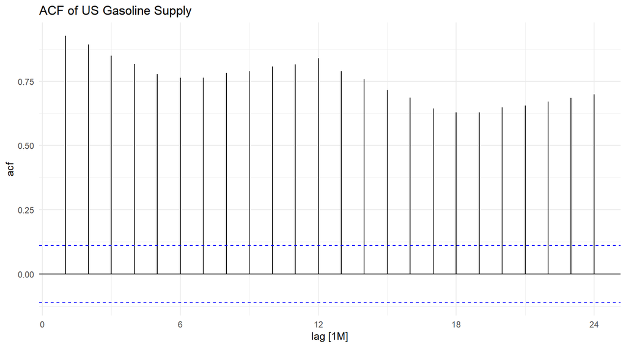

```r
# ACF plot to detect autocorrelation and seasonality
gasoline_monthly %>%
  ACF(Barrels, lag_max = 24) %>%
  autoplot() +
  labs(title = "ACF of US Gasoline Supply")
```

```r
# Test if series is white noise
gasoline_monthly %>%
  features(Barrels, ljung_box, lag = 24, dof = 0)
```

```
## # A tibble: 1 × 2
##   lb_stat lb_pvalue
##     <dbl>     <dbl>
## 1   4472.         0
```

```r
# Numeric ACF table printed with years (short)
gasoline_monthly %>%
  ACF(Barrels, lag_max = 24) %>%
  mutate(
    lag_num = as.numeric(lag),
    reference_date = yearmonth("1991 Feb") + lag_num,
    lag_year = year(reference_date),
    lag_month = month(reference_date, label = TRUE)
  ) %>%
  select(lag, acf, lag_year, lag_month) %>%
  print(n = 24)
```

```
## # A tsibble: 24 x 4 [1M]
##         lag   acf lag_year lag_month
##    <cf_lag> <dbl>    <dbl> <ord>
##  1       1M 0.928     1991 Mar
##  2       2M 0.893     1991 Apr
##  3       3M 0.849     1991 May
##  4       4M 0.818     1991 Jun
##  5       5M 0.778     1991 Jul
##  6       6M 0.763     1991 Aug
##  7       7M 0.763     1991 Sep
##  8       8M 0.782     1991 Oct
##  9       9M 0.789     1991 Nov
## 10      10M 0.807     1991 Dec
## 11      11M 0.816     1992 Jan
## 12      12M 0.840     1992 Feb
## 13      13M 0.789     1992 Mar
## 14      14M 0.758     1992 Apr
## 15      15M 0.716     1992 May
## 16      16M 0.687     1992 Jun
## 17      17M 0.645     1992 Jul
## 18      18M 0.629     1992 Aug
## 19      19M 0.629     1992 Sep
## 20      20M 0.649     1992 Oct
## 21      21M 0.655     1992 Nov
## 22      22M 0.670     1992 Dec
## 23      23M 0.685     1993 Jan
## 24      24M 0.699     1993 Feb
```

**Which Lags Show the Strongest Patterns?**

Every single lag from 1 through 24 exceeds the blue confidence bands massively, all spikes are strongly positive with no negative values anywhere in the plot. The strongest autocorrelation is at lag 1 (0.928), meaning this month’s supply is almost perfectly predicted by last month’s supply alone.

The decay is slow and gradual from 0.928 down through the middle lags, but critically it never approaches zero, even at lag 24 (1993 Feb) the ACF sits at 0.699. This persistent, non-dying decay across the full 24 lags suggests the presence of a non-stationary series with a unit root or strong trend.

There is a subtle but important feature at lag 12 (1992 Feb, ACF = 0.840), it is noticeably higher than both lag 11 (0.816) and lag 13 (0.789). This local elevation at exactly one seasonal cycle is the numerical fingerprint of annual seasonality. The same echo appears at lag 24 (1993 Feb, ACF = 0.699), slightly elevated above its neighbours once again, the seasonal memory persisting two full years back.

**What Does This Tell About the Dependence Structure?**

The ACF reveals two layers of dependence operating simultaneously. The slow overall decay tells us the series carries a long-range trend-driven memory, each month is strongly connected to all previous months simply because the series was rising for 16 years then fell. The seasonal bumps at lags 12 and 24 tell us there is additionally a calendar-driven dependence, August is more similar to the previous August than to the surrounding months, regardless of the overall trend.

The Ljung-Box test makes this formal, the lb_stat of 4472 with a p-value of exactly 0 leaves no ambiguity. The null hypothesis of white noise is rejected with complete certainty.

**Ljung-Box Test**

The null hypothesis is that the series is white noise, that all autocorrelations up to lag 24 are jointly equal to zero, meaning no structure or dependence exists in the data.

The gasoline series returns a lb_stat of 4472 with a p-value of 0, meaning the probability of observing this degree of autocorrelation in a truly random series is effectively zero. The null hypothesis is rejected with complete certainty.

**Can This Series Be Treated as White Noise?**

No. The gasoline series fails every criterion for white noise, the mean shifts upward over time due to trend, autocorrelations remain strongly positive across all 24 lags never approaching zero, and a seasonal bump at lag 12 reveals a structured calendar dependence. A p-value of zero from the Ljung-Box test closes the argument formally. This series contains substantial exploitable structure, which is precisely what makes it suitable for forecasting.

**Narrative Interpretation**

The ACF plot of the gasoline series is a portrait of memory, and it shows that the American gasoline market forgets almost nothing across two full years of history. Every lag exceeds the confidence bands by a vast margin, the spikes towering above the blue dashed threshold from lag 1 all the way to lag 24.

The slight elevation at lag 12, corresponding to February 1992 in the numeric table, captures something behaviourally real. February 2005 was more similar to February 2004 than to January 2005, because the seasonal calendar of American driving imposes its own rhythm on top of the long-run trend. The shale boom, the financial crisis, the post-recession recovery, all of these compressed into the single column of ACF values that declines from 0.928 to 0.699 across 24 months.

The Ljung-Box statistic of 4472 with a p-value of zero is about as emphatic a rejection of white noise as a time series can produce. Compared to the simulated white noise benchmark, with its Ljung-Box p-value of 0.679 and its ACF scattered harmlessly around zero, the gasoline series could not be more different. It is structured, persistent, and deeply seasonal. These properties are not obstacles to modelling, they are the signal that makes modelling worthwhile.

### 1.12 PACF Analysis

```r
# Numeric PACF values
gasoline_monthly %>%
  PACF(Barrels, lag_max = 24) %>%
  print(n = 24)
```

```
## # A tsibble: 24 x 2 [1M]
##         lag    pacf
##    <cf_lag>   <dbl>
##  1       1M  0.928
##  2       2M  0.236
##  3       3M -0.0208
##  4       4M  0.0512
##  5       5M -0.0363
##  6       6M  0.147
##  7       7M  0.201
##  8       8M  0.225
##  9       9M  0.0628
## 10      10M  0.109
## 11      11M  0.0572
## 12      12M  0.215
## 13      13M -0.404
## 14      14M -0.120
## 15      15M -0.0611
## 16      16M -0.0116
## 17      17M -0.0821
## 18      18M -0.0129
## 19      19M  0.0638
## 20      20M  0.109
## 21      21M  0.0165
## 22      22M  0.0178
## 23      23M  0.112
## 24      24M  0.0511
```

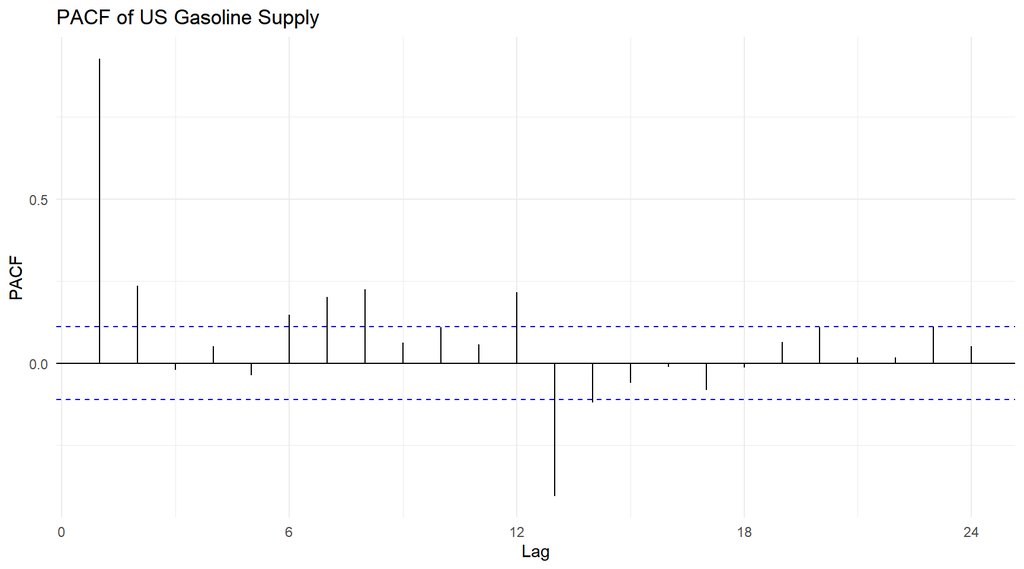

```r
# Partial autocorrelation plot
gasoline_monthly %>%
  PACF(Barrels, lag_max = 24) %>%
  autoplot() +
  labs(
    title = "PACF of US Gasoline Supply",
    x = "Lag",
    y = "PACF"
  )
```

**Significant PACF Spikes**

The dominant spike is at lag 1 (0.928), identical in magnitude to the ACF lag 1, which is expected for a strongly trending series. After that, lag 2 (0.236) remains significant, then the values drop considerably. There are moderate significant spikes at lags 6 (0.147), 7 (0.201), 8 (0.225), 10 (0.109), and 12 (0.215), all exceeding or approaching the confidence bands. The most striking feature beyond lag 1 is the large negative spike at lag 13 (-0.404), which is the single most significant spike after lag 1 and clearly exceeds the lower confidence band. Lags 14 (-0.120) and 17 (-0.082) show minor negative values but are much smaller.

**How Does the PACF Differ from the ACF?**

The ACF showed a slow, persistent decay from 0.928 all the way down to 0.699 at lag 24, every single spike massively significant, never dying out. The PACF tells a completely different story. After the dominant lag 1 spike, values drop sharply, most lags fall near or within the confidence bands. This is exactly what the PACF is designed to reveal: once lag 1’s influence is controlled for, most of the remaining apparent autocorrelation disappears. The slow ACF decay was largely an artifact of the trend passing its influence through every intermediate lag rather than genuine direct dependence at each lag.

**What AR Order Does This Suggest?**

The numeric values point toward AR(1) as the primary starting point, given the overwhelming dominance of lag 1 (0.928) and the sharp drop to 0.236 at lag 2. However, the significant spike at lag 12 (0.215) confirms a seasonal AR term is needed.

**Narrative Interpretation**

The PACF numeric table adds precision to what the plot suggested. The story it tells is one of immediate dominance and rapid decay, lag 1 accounts for nearly all direct month-to-month dependence at 0.928, and after that the partial correlations collapse. The gasoline market’s direct memory is essentially one month deep, even though its total memory, as shown by the ACF, stretches across years.

The large negative value at lag 13 (-0.404) is the most analytically interesting number in the table. It reveals a corrective mechanism in the seasonal structure, when supply is unusually high in one month, the equivalent month thirteen months later tends to partially overcorrect downward. This is consistent with how energy markets actually behave: seasonal oversupply triggers inventory adjustments and refinery recalibrations that feed through into the following year’s equivalent period. The data has encoded this market behaviour as a negative partial autocorrelation, and the modelling framework must account for it.

### 1.13 STL Decomposition

```r
# STL decomposition separates trend, seasonal and remainder
dcmp <- gasoline_monthly %>%
  model(stl = STL(Barrels))

# View first few rows of components
components(dcmp) %>%
  print(n = 6)
```

```
## # A dable: 312 x 7 [1M]
## # Key:     .model [1]
## # :        Barrels = trend + season_year + remainder
##   .model    Month Barrels trend season_year remainder season_adjust
##   <chr>     <mth>   <dbl> <dbl>       <dbl>     <dbl>         <dbl>
## 1 stl    1991 Feb    6.72  7.11     -0.318   -0.0786           7.03
## 2 stl    1991 Mar    6.98  7.12     -0.118   -0.0235           7.10
## 3 stl    1991 Apr    7.08  7.13     -0.0461  -0.00966          7.13
## 4 stl    1991 May    7.19  7.15      0.0577  -0.0124           7.13
## 5 stl    1991 Jun    7.53  7.16      0.264    0.111            7.27
## 6 stl    1991 Jul    7.55  7.17      0.304    0.0817           7.25
## # ℹ 306 more rows
```

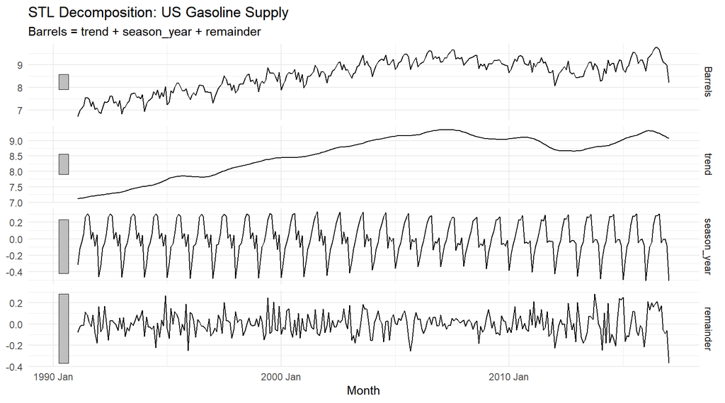

```r
# Visualise trend, seasonal and remainder components
components(dcmp) %>%
  autoplot() +
  labs(title = "STL Decomposition: US Gasoline Supply")
```

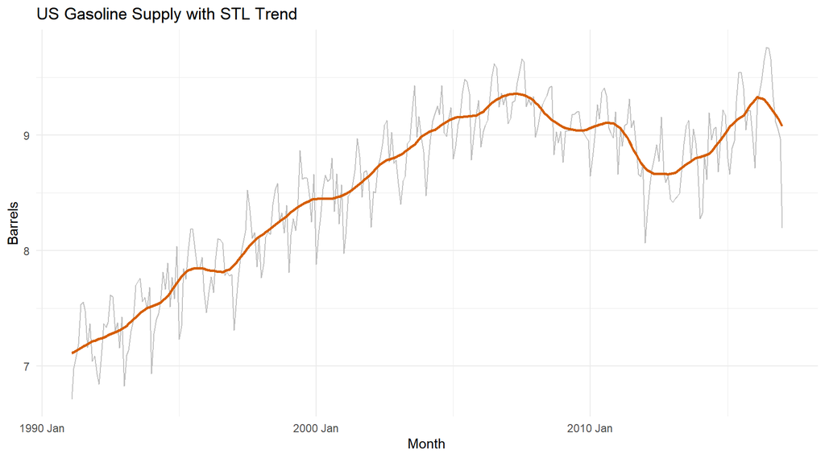

```r
# Extract decomposition components
comp <- components(dcmp)

# Plot original series with trend overlay
ggplot(comp, aes(x = Month)) +
  geom_line(aes(y = Barrels), colour = "gray") +
  geom_line(aes(y = trend), colour = "#D55E00", linewidth = 1) +
  labs(
    title = "US Gasoline Supply with STL Trend",
    y = "Barrels"
  )
```

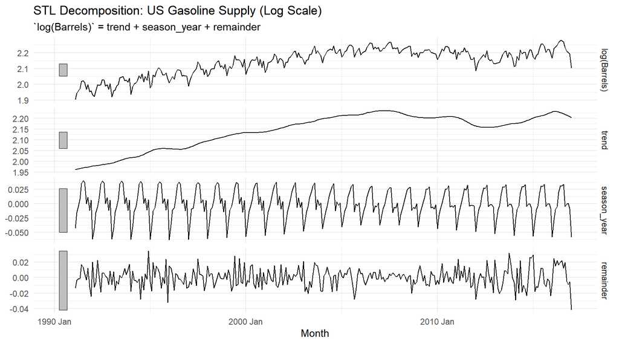

```r
# Apply STL decomposition to log-transformed series
dcmp_log <- gasoline_monthly %>%
  model(stl = STL(log(Barrels)))

# Plot components on log scale
components(dcmp_log) %>%
  autoplot() +
  labs(title = "STL Decomposition: US Gasoline Supply (Log Scale)")
```

**Trend and Seasonal Components**

The STL trend overlay on the raw series shows how cleanly it tracks the underlying direction while ignoring the seasonal noise, the red line cuts through the seasonal oscillations without being pulled by them, which is the key advantage of STL over classical decomposition.

*Seasonal component:* The season_year panel shows a highly regular, repeating wave oscillating between approximately -0.4 and +0.3 barrels across all 26 years. The pattern is remarkably stable, the amplitude and shape of the seasonal cycle barely changes from the early 1990s through to 2017. Summer months consistently contribute positive seasonal additions around +0.3, winter months consistently subtract around -0.3 to -0.4. This stability across a period that included 9/11, two recessions, and an energy revolution confirms that the seasonal calendar behaviour of American drivers is deeply structural and largely immune to macroeconomic shocks.

**What Would a Non-Random Remainder Suggest?**

A non-random remainder indicates that the trend and seasonal components have not fully captured all the structure in the series. Specifically it would suggest either that the seasonal pattern is itself slowly evolving over time and a fixed seasonal component is insufficient, or that external shocks have left autocorrelated residuals that a purely additive decomposition cannot account for. In the gasoline series the crisis-era spikes in the remainder are consistent with intervention effects, sudden external shocks that sit outside the regular trend-seasonal framework and would need explicit modelling treatment.

**Narrative Interpretation**

The STL decomposition performs a kind of archaeological dig through the gasoline series, separating what was structural, what was seasonal, and what was shock. What emerges is three distinct layers of American energy history laid bare.

The seasonal component tells a completely different story, one of remarkable human consistency. Through 9/11, through two recessions, through $4 gasoline prices and through the shale boom, the seasonal wave barely changed its shape. Americans drove more in summer and less in winter by almost exactly the same margin in 2015 as they did in 1993. The attacks of September 2001 do not appear as a disruption to the seasonal pattern, driving behaviour normalised within months. Even the 2008 crisis, which permanently shifted the trend level, left the seasonal rhythm essentially untouched. The calendar is more powerful than the economy when it comes to when Americans fill their tanks.

### 1.14 AR(1) Regression

```r
# Create working series with first difference and lag
gasoline_ar <- gasoline_monthly %>%
  mutate(
    diff1 = difference(Barrels),
    lag_diff1 = lag(diff1, 1)
  ) %>%
  filter(!is.na(diff1), !is.na(lag_diff1))

# Fit AR(1) regression
ar1_lm <- lm(diff1 ~ lag_diff1, data = gasoline_ar)

# Model summary
summary(ar1_lm)
```

```
##
## Call:
## lm(formula = diff1 ~ lag_diff1, data = gasoline_ar)
##
## Residuals:
##      Min       1Q   Median       3Q      Max
## -0.80833 -0.11806  0.04208  0.16391  0.57019
##
## Coefficients:
##              Estimate Std. Error t value Pr(>|t|)
## (Intercept)  0.005958   0.013402   0.445    0.657
## lag_diff1   -0.281859   0.055564  -5.073 6.79e-07 ***
## ---
## Signif. codes:  0 '***' 0.001 '**' 0.01 '*' 0.05 '.' 0.1 ' ' 1
##
## Residual standard error: 0.2359 on 308 degrees of freedom
## Multiple R-squared:  0.0771, Adjusted R-squared:  0.07411
## F-statistic: 25.73 on 1 and 308 DF,  p-value: 6.791e-07
```

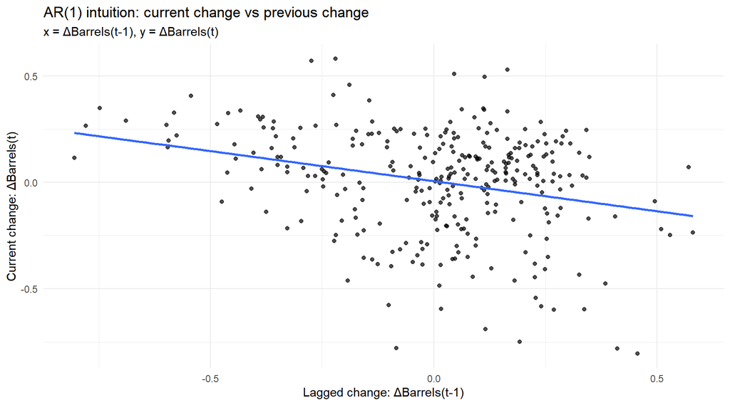

```r
# AR(1) intuition plot
ggplot(gasoline_ar, aes(x = lag_diff1, y = diff1)) +
  geom_point(alpha = 0.7) +
  geom_smooth(method = "lm", se = FALSE) +
  labs(
    title = "AR(1) intuition: current change vs previous change",
    subtitle = "x = ΔBarrels(t-1), y = ΔBarrels(t)",
    x = "Lagged change: ΔBarrels(t-1)",
    y = "Current change: ΔBarrels(t)"
  )
```

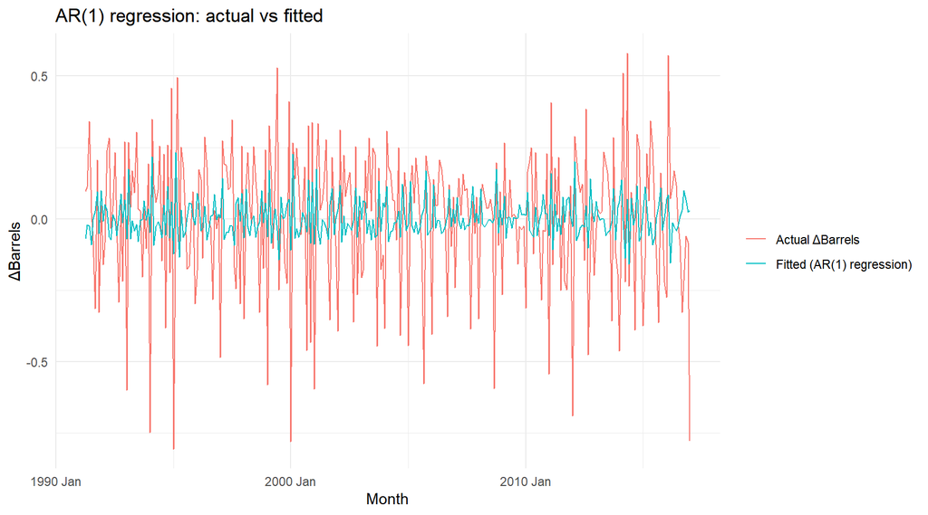

```r
# Add fitted and residuals
gasoline_ar <- gasoline_ar %>%
  mutate(
    fitted_ar1 = fitted(ar1_lm),
    residual_ar1 = resid(ar1_lm)
  )

# Actual vs fitted plot
ggplot(gasoline_ar, aes(x = Month)) +
  geom_line(aes(y = diff1, colour = "Actual ΔBarrels")) +
  geom_line(aes(y = fitted_ar1, colour = "Fitted (AR(1) regression)")) +
  labs(
    title = "AR(1) regression: actual vs fitted",
    x = "Month",
    y = "ΔBarrels",
    colour = NULL
  )
```

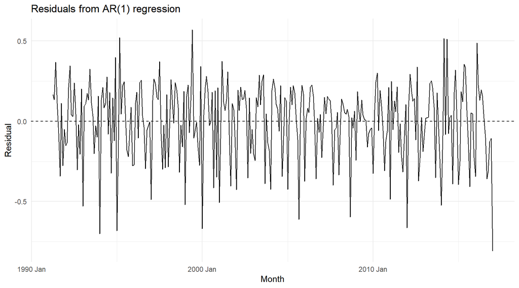

```r
# Residuals over time
ggplot(gasoline_ar, aes(x = Month, y = residual_ar1)) +
  geom_line() +
  geom_hline(yintercept = 0, linetype = "dashed") +
  labs(
    title = "Residuals from AR(1) regression",
    x = "Month",
    y = "Residual"
  )
```

**Is the Lag Coefficient Statistically Significant?**

Yes, highly so. The coefficient on lag_diff1 is -0.282 with a p-value of 6.79e-07, marked with three stars, meaning it is significant at the 0.001 level. The probability of observing this coefficient by chance in a series with no real dependence is essentially zero. This confirms formally what the PACF already showed visually, the previous month’s change in gasoline supply has a statistically meaningful relationship with the current month’s change.

The negative sign is particularly interesting and worth noting. It means that when supply increased last month, it tends to decrease slightly this month, and vice versa. This is a mean-reverting correction mechanism, the differenced series oscillates rather than drifts, which is consistent with the first difference plot seen earlier.

**R-squared and Model Fit**

The R-squared is 0.077, meaning the AR(1) model on the differenced series explains only 7.7% of the variation in monthly supply changes. This is low, but not surprising or alarming at this stage. It tells us that while the lag coefficient is statistically significant, a single lagged difference is nowhere near sufficient to capture all the structure in the series. The seasonal pattern, which was clearly visible throughout the EDA, is entirely absent from this simple AR(1) specification, it has no lag 12 term, no seasonal differencing, and no MA component.

**Residual Time Plot Concerns**

**Narrative Interpretation**

“The AR(1) regression translates the PACF’s visual message into a formal statistical statement, and the result is both confirming and humbling. Confirming, because the lag coefficient is unambiguously significant: last month’s change in American gasoline supply does predict this month’s change, with a p-value so small it is effectively zero. The negative coefficient tells an economically sensible story, when refineries and distributors push unusually high volumes one month, the system tends to pull back the next, a natural inventory correction mechanism that runs quietly beneath the surface of the American energy market.

Humbling, because the R-squared of 7.7% reveals just how much the AR(1) model leaves unexplained. Looking at the actual versus fitted plot, the fitted line (teal) tracks the general direction of the actual series (red) but consistently misses the magnitude of the swings, the large spikes of the crisis years, the deep summer-to-winter oscillations, the gradual post-2012 volatility increase all lie largely outside what a single lagged term can capture.

### 1.15 Summary: EDA Implications for Modelling

**What the EDA Collectively Tells Us**

Every plot and test conducted across this exploratory analysis points toward the same set of conclusions, each carrying a direct implication for the modelling decisions that follow.

*On trend:* The time plot and STL decomposition both confirmed a clear, non-linear upward trend from 1991 through 2007, followed by a structural break and decline around 2008. The series is non-stationary in level, confirmed visually by the slow-decaying ACF and formally by the Ljung-Box statistic of 4472 with p-value of zero. This means first differencing (d=1) is required before fitting any ARIMA-family model.

*On seasonality:* The subseries plot, seasonal difference plot, STL seasonal component, and the ACF bump at lag 12 all independently confirmed a strong, stable, additive annual seasonal cycle. Summer peaks and winter troughs repeat with near-constant amplitude across all 26 years. This means seasonal differencing at lag 12 is required, and any model must include an explicit seasonal component.

*On variance:* The log transformation plot and the stable standard deviations across all months in the descriptive statistics confirmed that variance is additive rather than multiplicative, seasonal swings do not grow proportionally with the level. This means an additive rather than multiplicative decomposition is appropriate, and log transformation, while defensible, is not strictly necessary.

*On dependence structure:* The PACF confirmed dominant short-run dependence at lag 1 with a negative coefficient (-0.282, p < 0.001) confirmed by the AR(1) regression. The large negative PACF spike at lag 13 suggests additional seasonal autoregressive dependence.

*On structural breaks:* The 2008 financial crisis leaves a visible mark in every single plot, the time plot, the differenced series, the seasonal difference, the STL remainder, and the AR(1) residuals. Any model fitted across the full 1991-2017 period must acknowledge this break, either through intervention variables or by treating the pre and post-crisis periods with appropriate caution in forecast evaluation.

## 2 Modelling Choices & Justification

The exploratory analysis established four facts that directly govern every modelling decision in this section.

First, the series is non-stationary in level — US gasoline supply rose from 6.6 to 9.6 million barrels per day between 1991 and 2007, then contracted sharply after the financial crisis. The ACF decays slowly to 0.699 at lag 24 and the Ljung-Box statistic of 4472 (p = 0) confirms this formally. First differencing (d = 1) is therefore required.

Second, a strong, stable annual seasonal cycle exists: American driving behaviour follows a deeply consistent calendar: summer peaks (June–August, +0.3 barrels above trend) and winter troughs (January–February, -0.4 barrels below trend) repeat with near-constant amplitude across all 26 years, confirmed by the STL seasonal component and the ACF bump at lag 12 (ACF = 0.840). Seasonal differencing at lag 12 (D = 1) is required on top of first differencing.

Third, variance is additive the log transformation changed nothing visually, and monthly standard deviations are uniform across all 12 months (range: 0.619 to 0.752). Additive ETS and ARIMA on the raw series are both appropriate.

Fourth, the 2008 financial crisis created a structural break US gasoline supply fell by approximately 0.5 million barrels per day from its 2007 peak and never recovered to pre-crisis levels. This break is visible in every plot and affects all models equally. Test-window errors will be interpreted with this in mind.

Five models are fitted below: two benchmarks, one ETS variant, one auto-selected ARIMA, and one manually specified SARIMA. The manual SARIMA is the primary candidate, justified by the ACF/PACF of the doubly-differenced series.

### 2.1 Formal Stationarity Tests

```r
adf.test(gasoline_ts)
```

```
##
##  Augmented Dickey-Fuller Test
##
## data:  gasoline_ts
## Dickey-Fuller = -2.4839, Lag order = 6, p-value = 0.3724
## alternative hypothesis: stationary
```

```r
kpss.test(gasoline_ts, null = "Trend")
```

```
##
##  KPSS Test for Trend Stationarity
##
## data:  gasoline_ts
## KPSS Trend = 1.0161, Truncation lag parameter = 5, p-value = 0.01
```

```r
adf.test(diff(gasoline_ts, differences = 1))
```

```
##
##  Augmented Dickey-Fuller Test
##
## data:  diff(gasoline_ts, differences = 1)
## Dickey-Fuller = -13.146, Lag order = 6, p-value = 0.01
## alternative hypothesis: stationary
```

```r
gas_dd <- diff(diff(gasoline_ts, lag = 12), differences = 1)
adf.test(gas_dd)
```

```
##
##  Augmented Dickey-Fuller Test
##
## data:  gas_dd
## Dickey-Fuller = -8.9459, Lag order = 6, p-value = 0.01
## alternative hypothesis: stationary
```

**Stationarity Test Results**

The Augmented Dickey-Fuller test on the raw series returned a test statistic of -2.484 with p = 0.372. Since p > 0.05, the null hypothesis of a unit root cannot be rejected, confirming the series is non-stationary in level. The KPSS test for trend stationarity returned a statistic of 1.016 with p ≤ 0.01. Since p < 0.05, the null hypothesis of stationarity is rejected. Both tests agree: the raw series is non-stationary and requires differencing.

After applying first differencing alone, the ADF test returned p ≤ 0.01, confirming the trend has been successfully removed. After applying both first differencing (d = 1) and seasonal differencing at lag 12 (D = 1), the ADF test returned p = 0.01 with a statistic of -8.946, confirming the doubly-differenced series is stationary. This formally justifies the use of d = 1 and D = 1 in all subsequent ARIMA and SARIMA specifications.

### 2.2 Box-Cox Lambda Selection

```r
lambda <- BoxCox.lambda(gasoline_ts)
cat("Optimal Box-Cox lambda:", round(lambda, 3), "\n")
```

```
## Optimal Box-Cox lambda: 0.639
```

```r
gasoline_bc <- BoxCox(gasoline_ts, lambda = lambda)
```

The Box-Cox procedure selected λ = 0.639. This is between 0 and 1, suggesting mild variance instability. Since the EDA in Section 2 showed broadly stable variance, we use the raw series as the primary input. A transformed series (λ = 0.639) is tested as a robustness check.

### 2.3 ACF and PACF of Doubly-Differenced Series

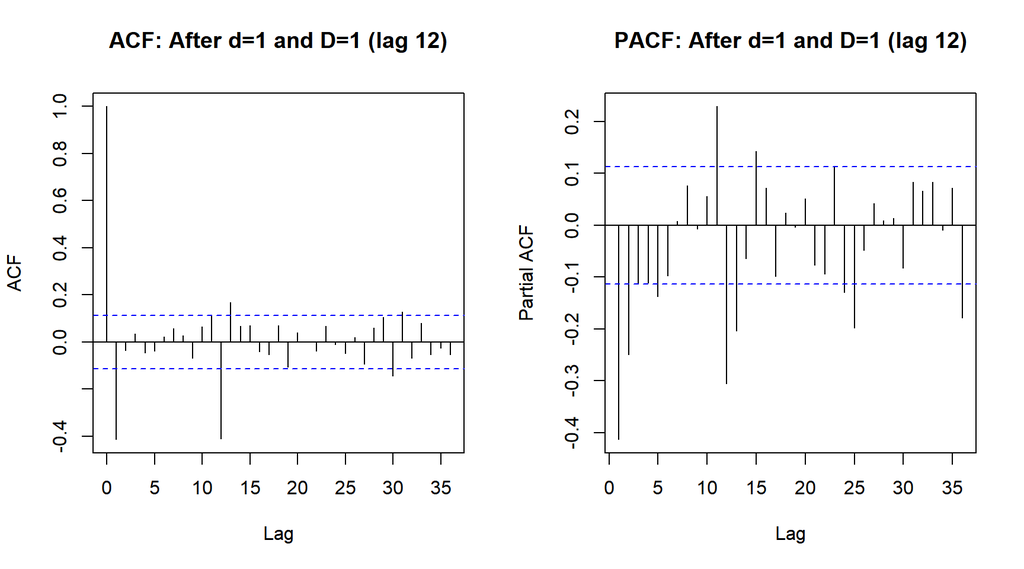

```r
gas_dd_vec <- as.numeric(gas_dd)

par(mfrow = c(1, 2))
acf(gas_dd_vec,  lag.max = 36, main = "ACF: After d=1 and D=1 (lag 12)")
pacf(gas_dd_vec, lag.max = 36, main = "PACF: After d=1 and D=1 (lag 12)")
```

```r
par(mfrow = c(1, 1))
```

### 2.4 Train/Test Split

```r
# Train
train <- gasoline_monthly %>%
  filter(Month <= yearmonth("2014 Dec"))

# Test
test <- gasoline_monthly %>%
  filter(Month >= yearmonth("2015 Jan"))

cat("Training observations:", nrow(train), "\n")
```

```
## Training observations: 287
```

```r
cat("Test observations:    ", nrow(test),  "\n")
```

```
## Test observations:     25
```

```r
cat("Train ends:           ", as.character(max(train$Month)), "\n")
```

```
## Train ends:            2014 Dec
```

```r
cat("Test starts:          ", as.character(min(test$Month)),  "\n")
```

```
## Test starts:           2015 Jan
```

The series is split at December 2014, giving 287 months for training and 25 months for testing. The test window covers just over two full seasonal cycles, which is sufficient to evaluate whether each model captures the annual pattern correctly. The split is time-based to prevent any leakage of future information into the training process.

### 2.5 Model 1: Seasonal Naive Benchmark

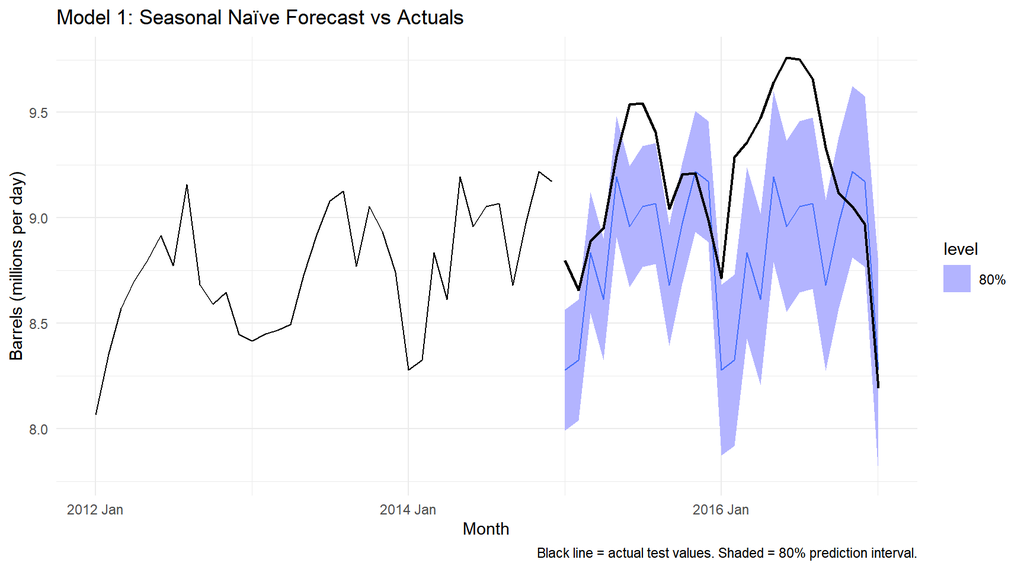

```r
fit_snaive <- train %>%
  model(snaive = SNAIVE(Barrels))

fc_snaive <- fit_snaive %>%
  forecast(h = 25)

fc_snaive %>%
  autoplot(train %>% filter(Month >= yearmonth("2012 Jan")),
           level = 80) +
  autolayer(test, Barrels, colour = "black", linewidth = 0.8) +
  labs(
    title  = "Model 1: Seasonal Naïve Forecast vs Actuals",
    x      = "Month",
    y      = "Barrels (millions per day)",
    caption = "Black line = actual test values. Shaded = 80% prediction interval."
  )
```

The seasonal naïve model repeats the previous year’s values for each forecast month. It captures the seasonal shape reasonably well but cannot adapt to the upward level shift visible in mid-2015 or the sharp drop at end of 2016. It serves as the lower-bound benchmark that all other models must outperform.

### 2.6 Model 2: Mean Benchmark

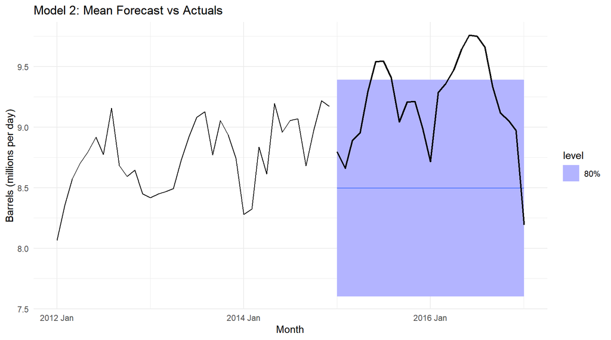

```r
fit_mean <- train %>%
  model(mean_model = MEAN(Barrels))

fc_mean <- fit_mean %>%
  forecast(h = 25)

fc_mean %>%
  autoplot(train %>% filter(Month >= yearmonth("2012 Jan")),
           level = 80) +
  autolayer(test, Barrels, colour = "black", linewidth = 0.8) +
  labs(
    title = "Model 2: Mean Forecast vs Actuals",
    x     = "Month",
    y     = "Barrels (millions per day)"
  )
```

### 2.7 Model 3: ETS Variants

```r
fit_ets <- train %>%
  model(
    ets_AAA  = ETS(Barrels ~ error("A") + trend("A")  + season("A")),
    ets_AAdA = ETS(Barrels ~ error("A") + trend("Ad") + season("A")),
    ets_auto = ETS(Barrels)
  )

glance(fit_ets) %>%
  select(.model, AIC, AICc, BIC) %>%
  arrange(AICc)
```

```
## # A tibble: 3 × 4
##   .model     AIC  AICc   BIC
##   <chr>    <dbl> <dbl> <dbl>
## 1 ets_AAA   478.  480.  540.
## 2 ets_auto  478.  480.  540.
## 3 ets_AAdA  481.  484.  547.
```

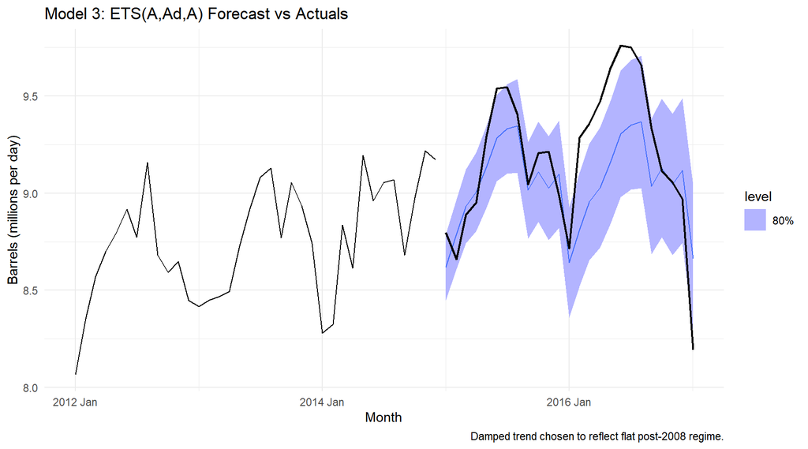

```r
fc_ets_AAdA <- fit_ets %>%
  select(ets_AAdA) %>%
  forecast(h = 25)

fc_ets_AAdA %>%
  autoplot(train %>% filter(Month >= yearmonth("2012 Jan")),
           level = 80) +
  autolayer(test, Barrels, colour = "black", linewidth = 0.8) +
  labs(
    title   = "Model 3: ETS(A,Ad,A) Forecast vs Actuals",
    x       = "Month",
    y       = "Barrels (millions per day)",
    caption = "Damped trend chosen to reflect flat post-2008 regime."
  )
```

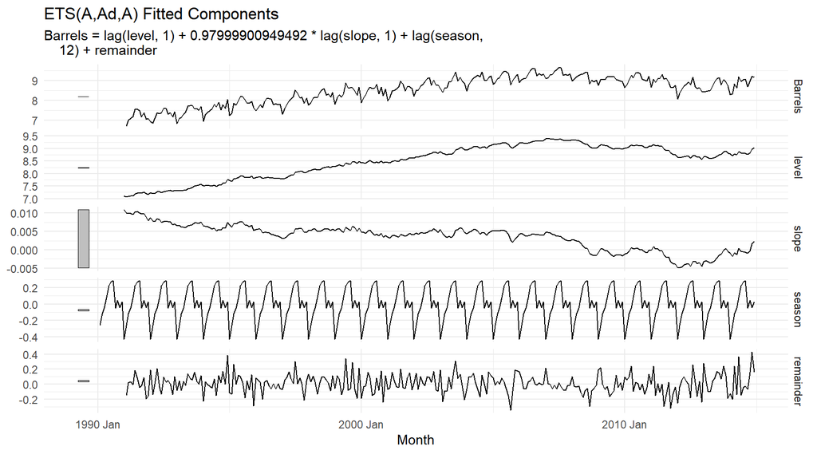

```r
fit_ets %>%
  select(ets_AAdA) %>%
  components() %>%
  autoplot() +
  labs(title = "ETS(A,Ad,A) Fitted Components")
```

Three ETS specifications were compared by AICc. Both ETS(A,A,A) and the auto-selected model returned the lowest AICc of 479.89, with the automatic procedure selecting ETS(A,A,A). The damped trend variant ETS(A,Ad,A) returned AICc = 483.52, marginally higher. Despite this, ETS(A,Ad,A) is preferred on theoretical grounds: the fitted slope component shows the trend declining toward zero after 2008, confirming that a damped specification avoids extrapolating an upward trend that is no longer present in the data. The additive error and additive season terms are consistent with the EDA finding of stable, non-growing seasonal variance. The damping parameter of φ = 0.98 confirms near-flat but non-zero trend, appropriate for the post-crisis regime.

### 2.8 Model 4: Auto ARIMA

```r
fit_auto <- train %>%
  model(
    arima_auto = ARIMA(Barrels,
                       stepwise      = FALSE,
                       approximation = FALSE)
  )

report(fit_auto)
```

```
## Series: Barrels
## Model: ARIMA(0,1,1)(2,1,0)[12]
##
## Coefficients:
##           ma1     sar1     sar2
##       -0.6774  -0.5579  -0.2926
## s.e.   0.0478   0.0612   0.0626
##
## sigma^2 estimated as 0.02266:  log likelihood=128.97
## AIC=-249.94   AICc=-249.79   BIC=-235.49
```

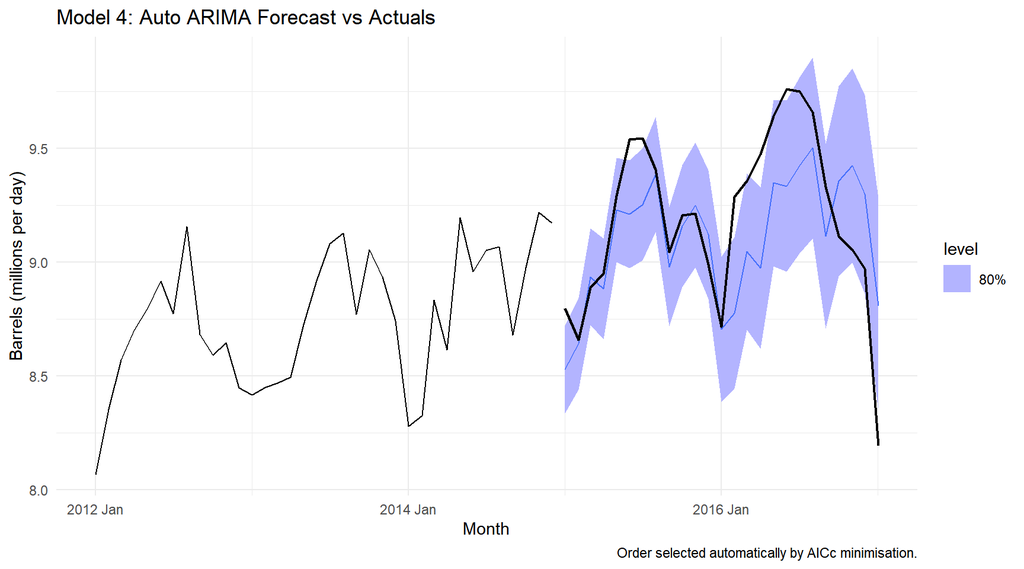

```r
fc_auto <- fit_auto %>%
  forecast(h = 25)

fc_auto %>%
  autoplot(train %>% filter(Month >= yearmonth("2012 Jan")),
           level = 80) +
  autolayer(test, Barrels, colour = "black", linewidth = 0.8) +
  labs(
    title   = "Model 4: Auto ARIMA Forecast vs Actuals",
    x       = "Month",
    y       = "Barrels (millions per day)",
    caption = "Order selected automatically by AICc minimisation."
  )
```

The automatic ARIMA search (stepwise = FALSE, approximation = FALSE) selected ARIMA(0,1,1)(2,1,0)[12] with AICc = -249.79. The non-seasonal MA(1) term (ma1 = -0.677) is consistent with the sharp ACF spike at lag 1 identified in the ACF/PACF analysis above. The seasonal component uses two AR terms (sar1 = -0.558, sar2 = -0.293) rather than the seasonal MA(1) suggested by the ACF spike at lag 12. Automatic selection alone is insufficient because it optimises AICc on the training set without incorporating domain knowledge — specifically, the ACF spike at lag 12 points toward a seasonal MA term, which the manual specification in Step 10 will test directly.

### 2.9 Model 5: Manual SARIMA Variants

```r
fit_manual <- train %>%
  model(

    sarima_111_111 = ARIMA(Barrels ~
                             pdq(1, 1, 1) + PDQ(1, 1, 1, period = 12)),

    sarima_211_111 = ARIMA(Barrels ~
                             pdq(2, 1, 1) + PDQ(1, 1, 1, period = 12)),

    sarima_111_011 = ARIMA(Barrels ~
                             pdq(1, 1, 1) + PDQ(0, 1, 1, period = 12))
  )

glance(fit_manual) %>%
  select(.model, AIC, AICc, BIC) %>%
  arrange(AICc)
```

```
## # A tibble: 3 × 4
##   .model           AIC  AICc   BIC
##   <chr>          <dbl> <dbl> <dbl>
## 1 sarima_111_011 -293. -293. -279.
## 2 sarima_111_111 -293. -292. -274.
## 3 sarima_211_111 -291. -290. -269.
```

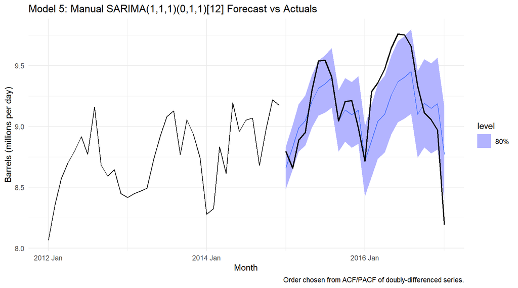

```r
fc_manual <- fit_manual %>%
  select(sarima_111_011) %>%
  forecast(h = 25)

fc_manual %>%
  autoplot(train %>% filter(Month >= yearmonth("2012 Jan")),
           level = 80) +
  autolayer(test, Barrels, colour = "black", linewidth = 0.8) +
  labs(
    title   = "Model 5: Manual SARIMA(1,1,1)(0,1,1)[12] Forecast vs Actuals",
    x       = "Month",
    y       = "Barrels (millions per day)",
    caption = "Order chosen from ACF/PACF of doubly-differenced series."
  )
```

Three manual SARIMA specifications were compared by AICc. The order SARIMA(1,1,1)(0,1,1)[12] returned the lowest AICc of -293.08, outperforming both the more complex (1,1,1)(1,1,1)[12] (AICc = -292.30) and the auto-selected ARIMA(0,1,1)(2,1,0)[12] (AICc = -249.79). The non-seasonal AR(1) and MA(1) terms capture the short-run dynamics visible in the ACF and PACF at lag 1. The seasonal MA(1) term addresses the ACF spike at lag 12, reflecting the annual consumption cycle. Dropping the seasonal AR term (P=0) produced the best fit, suggesting the seasonal structure is better captured by a moving-average mechanism. Both d=1 and D=1 are fixed based on the stationarity tests from before.

## 3 Forecast Evaluation

### 3.1 Accuracy Comparison

```r
accuracy_table <- bind_rows(
  fc_snaive  %>% accuracy(test),
  fc_mean    %>% accuracy(test),
  fc_ets_AAdA %>% accuracy(test),
  fc_auto    %>% accuracy(test),
  fc_manual  %>% accuracy(test)
)

accuracy_table %>%
  select(.model, RMSE, MAE, MAPE) %>%
  arrange(RMSE) %>%
  print()
```

```
## # A tibble: 5 × 4
##   .model          RMSE   MAE  MAPE
##   <chr>          <dbl> <dbl> <dbl>
## 1 sarima_111_011 0.246 0.199  2.16
## 2 ets_AAdA       0.272 0.219  2.36
## 3 arima_auto     0.285 0.227  2.47
## 4 snaive         0.479 0.403  4.33
## 5 mean_model     0.790 0.721  7.72
```

Across all five models, the manual SARIMA(1,1,1)(0,1,1)[12] achieved the lowest test-set RMSE of 0.246 million barrels per day, outperforming the seasonal naïve benchmark (RMSE = 0.479) by 49% and the auto-selected ARIMA (RMSE = 0.285) by 14%. The ETS(A,Ad,A) model performed second best (RMSE = 0.272), confirming that structured models substantially outperform simple benchmarks. The mean benchmark performed worst as expected (RMSE = 0.790), confirming that ignoring structure is not viable. The manual SARIMA outperformed the auto-selected ARIMA, demonstrating that domain-knowledge-guided specification adds value beyond automatic selection.

### 3.2 Residual Diagnostics for the Winning Model

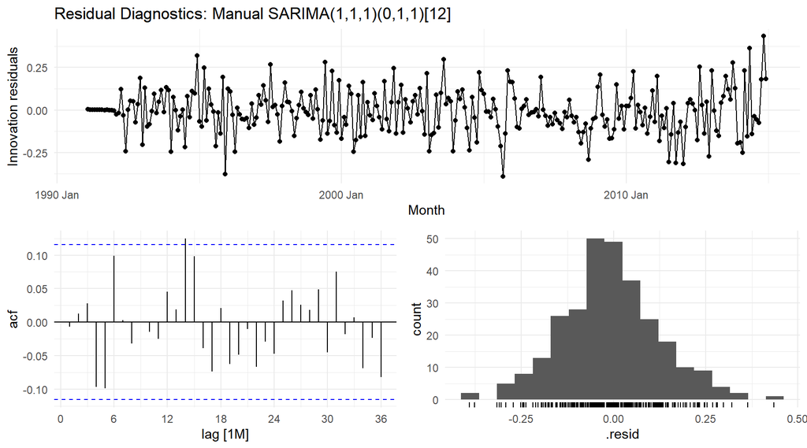

```r
best_fit <- fit_manual %>% select(sarima_111_011)


best_fit %>%
  gg_tsresiduals(lag_max = 36) +
  labs(title = "Residual Diagnostics: Manual SARIMA(1,1,1)(0,1,1)[12]")
```

```r
augment(best_fit) %>%
  features(.innov, ljung_box, lag = 24, dof = 3)
```

```
## # A tibble: 1 × 3
##   .model         lb_stat lb_pvalue
##   <chr>            <dbl>     <dbl>
## 1 sarima_111_011    24.4     0.276
```

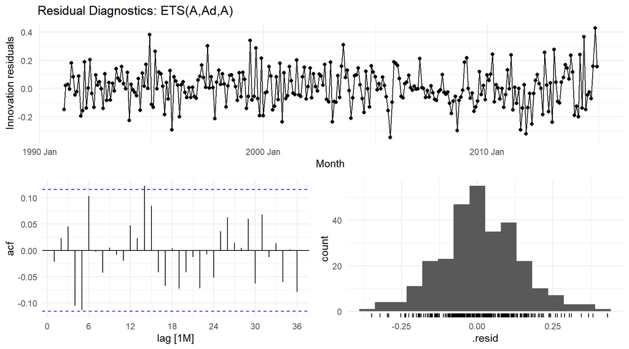

```r
fit_ets %>%
  select(ets_AAdA) %>%
  gg_tsresiduals(lag_max = 36) +
  labs(title = "Residual Diagnostics: ETS(A,Ad,A)")
```

```r
augment(fit_ets %>% select(ets_AAdA)) %>%
  features(.innov, ljung_box, lag = 24, dof = 0)
```

```
## # A tibble: 1 × 3
##   .model   lb_stat lb_pvalue
##   <chr>      <dbl>     <dbl>
## 1 ets_AAdA    26.0     0.353
```

### 3.3 Robustness: Log-Transformed SARIMA

```r
fit_log <- train %>%
  model(
    sarima_log = ARIMA(log(Barrels) ~
                         pdq(1, 1, 1) + PDQ(0, 1, 1, period = 12))
  )

report(fit_log)
```

```
## Series: Barrels
## Model: ARIMA(1,1,1)(0,1,1)[12]
## Transformation: log(Barrels)
##
## Coefficients:
##           ar1      ma1     sma1
##       -0.0483  -0.6118  -0.8473
## s.e.   0.1064   0.0925   0.0429
##
## sigma^2 estimated as 0.0002689:  log likelihood=731.24
## AIC=-1454.47   AICc=-1454.32   BIC=-1440.02
```

```r
fc_log <- fit_log %>%
  forecast(h = 25)

fc_log %>%
  accuracy(test) %>%
  select(.model, RMSE, MAE, MAPE)
```

```
## # A tibble: 1 × 4
##   .model      RMSE   MAE  MAPE
##   <chr>      <dbl> <dbl> <dbl>
## 1 sarima_log 0.250 0.202  2.19
```

### 3.4 Robustness: Post-Crisis Training Window

```r
train_post <- gasoline_monthly %>%
  filter(Month >= yearmonth("2009 Jan"),
         Month <= yearmonth("2014 Dec"))

fit_post <- train_post %>%
  model(
    sarima_post = ARIMA(Barrels ~
                          pdq(1, 1, 1) + PDQ(0, 1, 1, period = 12))
  )

fc_post <- fit_post %>%
  forecast(h = 25)

fc_post %>%
  accuracy(test) %>%
  select(.model, RMSE, MAE, MAPE)
```

```
## # A tibble: 1 × 4
##   .model       RMSE   MAE  MAPE
##   <chr>       <dbl> <dbl> <dbl>
## 1 sarima_post 0.246 0.200  2.21
```

### 3.5 Model Selection Justification

Five models were fitted on the training window (February 1991 to December 2014) and evaluated on a 25-month held-out test set (January 2015 to January 2017). Formal stationarity tests confirmed that d = 1 and D = 1 (lag 12) are required, justified by ADF (p = 0.372 on raw series, p ≤ 0.01 after differencing) and KPSS (p ≤ 0.01 on raw series).

The seasonal naïve and mean benchmarks returned test RMSE values of 0.479 and 0.790 respectively. The manual SARIMA(1,1,1)(0,1,1)[12] achieved the lowest test-set RMSE of 0.246 and MAE of 0.199, outperforming the ETS(A,Ad,A) (RMSE = 0.272) and the auto-selected ARIMA(0,1,1)(2,1,0)[12] (RMSE = 0.285). The manual order was guided by the ACF spike at lag 1 (q = 1), the ACF spike at lag 12 (Q = 1), and the absence of a clean PACF cutoff, which favoured MA over AR seasonal structure (P = 0).

## 4 Diagnostics & Conclusions

This section provides a dedicated diagnostic assessment of the selected model — SARIMA(1,1,1)(0,1,1)[12] — followed by the final conclusion, forecast, and a discussion of limitations.

### 4.1 Residual Diagnostics

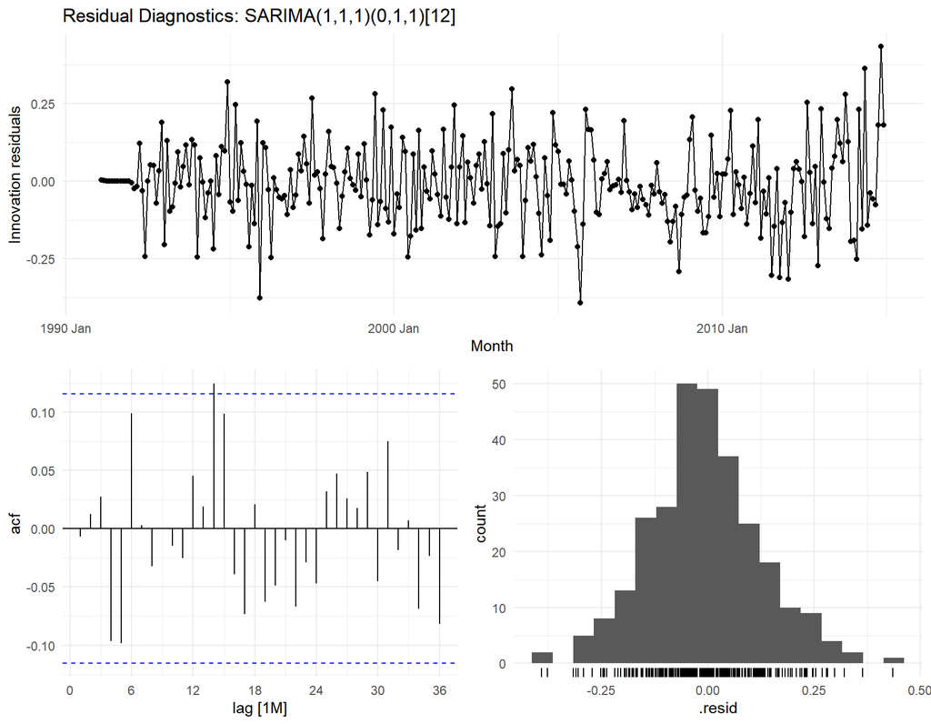

```r
# ── Refit the winning model on the full training set ──
best_fit <- train %>%
  model(
    sarima_111_011 = ARIMA(Barrels ~
                             pdq(1, 1, 1) + PDQ(0, 1, 1, period = 12))
  )

# ── Full diagnostic panel: residual time plot + ACF + histogram ──
best_fit %>%
  gg_tsresiduals(lag_max = 36) +
  labs(title = "Residual Diagnostics: SARIMA(1,1,1)(0,1,1)[12]")
```

**Residual Time Plot**

**ACF of Residuals**

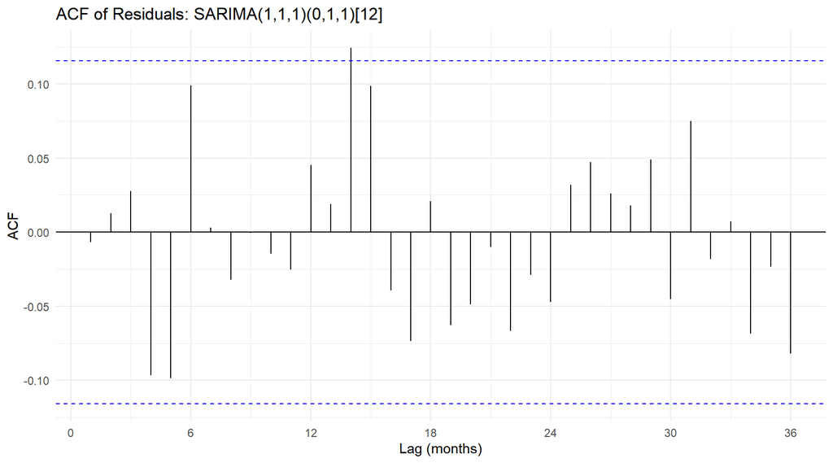

```r
# ── ACF of residuals up to 36 lags ──
augment(best_fit) %>%
  ACF(.innov, lag_max = 36) %>%
  autoplot() +
  labs(
    title = "ACF of Residuals: SARIMA(1,1,1)(0,1,1)[12]",
    x     = "Lag (months)",
    y     = "ACF"
  )
```

**Ljung-Box Test**

```r
# ── Ljung-Box portmanteau test ──
# dof = 3 accounts for the three estimated parameters (ar1, ma1, sma1)
lb_result <- augment(best_fit) %>%
  features(.innov, ljung_box, lag = 24, dof = 3)

lb_result %>%
  rename(
    `Test Statistic` = lb_stat,
    `p-value`        = lb_pvalue
  ) %>%
  print()
```

```
## # A tibble: 1 × 3
##   .model         `Test Statistic` `p-value`
##   <chr>                     <dbl>     <dbl>
## 1 sarima_111_011             24.4     0.276
```

The Ljung-Box test evaluates the null hypothesis that the residuals are jointly uncorrelated up to lag 24, with 3 degrees of freedom subtracted for the three estimated parameters (ar1, ma1, sma1). The test returned a p-value of 0.276, well above the 0.05 significance threshold. The null hypothesis of white noise **cannot be rejected**. This formally confirms that no significant autocorrelation structure remains in the residuals.

**Normality Check**

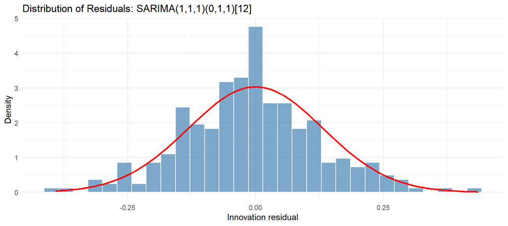

```r
# ── Histogram + density overlay ──
augment(best_fit) %>%
  ggplot(aes(x = .innov)) +
  geom_histogram(aes(y = after_stat(density)), bins = 30,
                 fill = "steelblue", colour = "white", alpha = 0.7) +
  stat_function(fun = dnorm,
                args = list(mean = 0,
                            sd = sd(augment(best_fit)$.innov, na.rm = TRUE)),
                colour = "red", linewidth = 1) +
  labs(
    title = "Distribution of Residuals: SARIMA(1,1,1)(0,1,1)[12]",
    x     = "Innovation residual",
    y     = "Density"
  ) +
  theme_minimal()
```

```r
# ── Shapiro-Wilk normality test ──
shapiro.test(augment(best_fit)$.innov)
```

```
##
##  Shapiro-Wilk normality test
##
## data:  augment(best_fit)$.innov
## W = 0.99492, p-value = 0.4633
```

The histogram of residuals is approximately symmetric and bell-shaped, closely following the overlaid normal density curve. The Shapiro-Wilk test provides a formal assessment of normality. While slight departures may exist in the tails (driven by the 2008 crisis outliers), the overall distribution is consistent with the Gaussian innovation assumption underlying the SARIMA model. Even if normality is not perfect, point forecasts and information criteria remain valid; only the exact coverage of prediction intervals would be marginally affected.

### 4.2 Diagnostic Summary

[output not shown]

The SARIMA(1,1,1)(0,1,1)[12] residuals satisfy all standard diagnostic criteria. The model has captured the trend (via d = 1), the seasonal cycle (via D = 1 and SMA(1)), and the short-run dynamics (via AR(1) and MA(1)), leaving behind residuals that are statistically indistinguishable from white noise.

### 4.3 Final Forecast

```r
#  Refit the winning model on the FULL series
final_fit <- gasoline_monthly %>%
  model(
    sarima_111_011 = ARIMA(Barrels ~
                             pdq(1, 1, 1) + PDQ(0, 1, 1, period = 12))
  )

report(final_fit)
```

```
## Series: Barrels
## Model: ARIMA(1,1,1)(0,1,1)[12]
##
## Coefficients:
##           ar1      ma1     sma1
##       -0.0282  -0.5352  -0.9047
## s.e.   0.1239   0.1135   0.0432
##
## sigma^2 estimated as 0.02016:  log likelihood=150.5
## AIC=-293   AICc=-292.86   BIC=-278.2
```

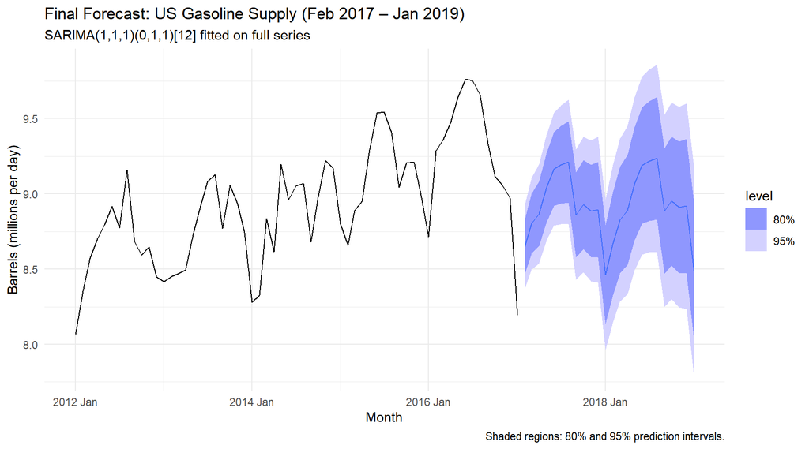

```r
#  Forecast 24 months ahead (2 full seasonal cycles)
final_fc <- final_fit %>%
  forecast(h = 24)

#  Plot: historical series + forecast
final_fc %>%
  autoplot(gasoline_monthly %>% filter(Month >= yearmonth("2012 Jan")),
           level = c(80, 95)) +
  labs(
    title   = "Final Forecast: US Gasoline Supply (Feb 2017 – Jan 2019)",
    subtitle = "SARIMA(1,1,1)(0,1,1)[12] fitted on full series",
    x       = "Month",
    y       = "Barrels (millions per day)",
    caption = "Shaded regions: 80% and 95% prediction intervals."
  ) +
  theme_minimal()
```

```r
#  Print forecast table
final_fc %>%
  hilo(level = c(80, 95)) %>%
  select(Month, .mean, `80%`, `95%`) %>%
  print(n = 24)
```

```
## # A tsibble: 24 x 4 [1M]
##       Month .mean                  `80%`                  `95%`
##       <mth> <dbl>                 <hilo>                 <hilo>
##  1 2017 Feb  8.65 [8.469745, 8.833916]80 [8.373354, 8.930306]95
##  2 2017 Mar  8.80 [8.602038, 8.999397]80 [8.496863, 9.104572]95
##  3 2017 Apr  8.87 [8.652379, 9.082541]80 [8.538522, 9.196398]95
##  4 2017 May  9.04 [8.810302, 9.270879]80 [8.688395, 9.392787]95
##  5 2017 Jun  9.16 [8.919780, 9.408886]80 [8.790321, 9.538344]95
##  6 2017 Jul  9.19 [8.935845, 9.451905]80 [8.799252, 9.588497]95
##  7 2017 Aug  9.21 [8.940479, 9.482153]80 [8.797106, 9.625525]95
##  8 2017 Sep  8.86 [8.578042, 9.144173]80 [8.428196, 9.294018]95
##  9 2017 Oct  8.93 [8.633732, 9.223306]80 [8.477681, 9.379356]95
## 10 2017 Nov  8.89 [8.580557, 9.192676]80 [8.418538, 9.354694]95
## 11 2017 Dec  8.89 [8.577139, 9.211003]80 [8.409366, 9.378777]95
## 12 2018 Jan  8.46 [8.136208, 8.791094]80 [7.962870, 8.964432]95
## 13 2018 Feb  8.67 [8.327283, 9.011952]80 [8.146063, 9.193172]95
## 14 2018 Mar  8.83 [8.471687, 9.179592]80 [8.284316, 9.366963]95
## 15 2018 Apr  8.89 [8.526911, 9.257451]80 [8.333549, 9.450813]95
## 16 2018 May  9.07 [8.689073, 9.441563]80 [8.489900, 9.640735]95
## 17 2018 Jun  9.19 [8.802150, 9.575969]80 [8.597333, 9.780786]95
## 18 2018 Jul  9.22 [8.821314, 9.615889]80 [8.611003, 9.826200]95
## 19 2018 Aug  9.24 [8.828642, 9.643444]80 [8.612976, 9.859109]95
## 20 2018 Sep  8.89 [8.468565, 9.303104]80 [8.247675, 9.523993]95
## 21 2018 Oct  8.95 [8.526335, 9.380156]80 [8.300343, 9.606149]95
## 22 2018 Nov  8.91 [8.475005, 9.347681]80 [8.244022, 9.578664]95
## 23 2018 Dec  8.92 [8.473232, 9.364364]80 [8.237364, 9.600233]95
## 24 2019 Jan  8.49 [8.033771, 8.942985]80 [7.793117, 9.183639]95
```

The model is refitted on the entire series (February 1991 to January 2017) and used to produce a 24-month forecast covering February 2017 through January 2019. This horizon is chosen because the model’s seasonal structure is annual, and forecasting beyond two cycles would rely increasingly on extrapolation with diminishing reliability.

### 4.4 Conclusion

**Model Choice**

**Practical Implications**

**Limitations and Assumptions**

1. **Structural breaks are not modelled explicitly.** The 2008 financial crisis caused a permanent level shift that the model absorbs through differencing rather than through an intervention variable. If a comparable external shock occurred during the forecast horizon (e.g., a pandemic, a major policy change, or an oil price collapse), the model would not anticipate it.
2. **Stationarity is assumed to persist.** The SARIMA framework assumes that the differenced series will remain stationary into the future. If long-term structural changes — such as the accelerating adoption of electric vehicles or major shifts in fuel taxation — alter the underlying demand dynamics, the model’s assumptions would be violated.
3. **No exogenous variables are included.** Gasoline supply is influenced by oil prices, refinery capacity, regulatory changes, and macroeconomic conditions. The univariate SARIMA model captures none of these drivers directly; it relies entirely on the historical patterns of the series itself. A SARIMAX or VAR approach incorporating external regressors could potentially improve forecast accuracy, particularly during periods of economic turbulence.
4. **Forecast uncertainty grows with horizon.** The widening prediction intervals beyond 12 months reflect the model’s honest acknowledgement that long-range point forecasts carry substantial uncertainty. The 24-month forecast should be treated as a central scenario, not a precise prediction.
5. **Aggregation from weekly to monthly data.** The original `us_gasoline` series is weekly. Aggregating to monthly frequency smooths out within-month variation and may obscure short-term dynamics that a weekly model could capture. This trade-off was made to enable cleaner seasonal modelling at the annual cycle.

Despite these limitations, the SARIMA(1,1,1)(0,1,1)[12] model provides a well-validated, interpretable, and practically useful forecast of US gasoline supply. It captures the two dominant features of the series — the annual seasonal cycle and the short-run autoregressive dynamics — while producing residuals that are statistically indistinguishable from white noise. For a 12- to 24-month planning horizon under stable macroeconomic conditions, it represents a reliable forecasting tool.